# GCM for $2\nu\beta\beta$ decay without using closure approximation

- For the $2\nu\beta\beta$ decay, $$ (Z,A) \to (Z+2, A) + 2e^- + 2\bar\nu_e, $$ the $Q_{\beta\beta}$ value is contributed by two parts: rest-mass loss and binding energy difference

\begin{align} Q_{\beta\beta} &= [Z*m_p + (A-Z)*m_n] - [(Z+2)*m_p + (A-Z-2)*m_n] - 2*m_e + B(Z+2,A) - B(Z,A)\nonumber \\ &= 2(m_n-m_p-m_e) + [B(Z+2,A) - B(Z,A)] \nonumber\\ &= 2(m_n-m_p-m_e) - [E(Z+2,A) - E(Z,A)] \nonumber\\ &= E(Z,A)-E(Z+2,A)+1.56 \end{align}

The measured halflife is [R. Arnold et al. (NEMO-3 Collaboration), Phys. Rev. D 93, 112008 (2016)](https://journals.aps.org/prd/abstract/10.1103/PhysRevD.93.112008) $$ T^{exp}_{1/2}= (6.4 \pm 1.2) \times 10^{19} yr $$

The inverse of the halflife is determined by

$$ T^{-1}_{2\nu}= G_{2\nu} g^4_A \vert M^{2\nu}\vert^2 $$ where the phase-space factor $G_{2\nu}=15550\times 10^{-21} yr$ [J. Kotila and F. Iachello, Phys. Rev. C 85, 034316 (2012)](https://journals.aps.org/prc/abstract/10.1103/PhysRevC.85.034316). It indicates that the derived NME (using 0.77 quenching factor) from the data is

$$ \vert M^{2\nu}\vert = \sqrt{1/[g^4_A T_{2\nu}*G_{2\nu}]}=\sqrt{1/(g^4_A*995.2)} = 0.0342 $$

```python
np.sqrt(1/((1.25*0.77)**4*995.2))
```

```
0.034217111104130456
```

- The nuclear matrix element of $2\nu\beta\beta$ decay is given by

$$ M^{2\nu} = \sum_k\dfrac{\langle 0^+_f\vert\vert \sigma\tau^- \vert\vert 1^+_m\rangle \langle 1^+_m\vert\vert\sigma\tau^- \vert\vert 0^+_i\rangle}{E(1^+_m) - [E(0^+_i+E(0^+_f)]/2} $$ Using the relation $Q_{\beta\beta} = E(0^+_i)-E(0^+_f)+1.56$, one has $$ [E(0^+_i)+E(0^+_f)]/2 = E(0^+_i) - [E(0^+_i)-E(0^+_f)]/2 = E(0^+_i) - (Q_{\beta\beta}-1.56)/2 $$ The denominator can be rewritten as \begin{align} E(1^+_m) - [E(0^+_i+E(0^+_f)]/2 &= E(1^+_m)- E(0^+_i) + (Q_{\beta\beta}-1.56)/2 \nonumber\\ &= E_x(1^+_m) + E_{g.s.}(Z+1,A) - E(0^+_i) + (Q_{\beta\beta}-1.56)/2. \end{align} where the *experimental data* for the energy difference between the ground-state of the initial nucleus (Z, A) and intermediate nucleus (Z+1, A) for $Z=20, A=48$ is $$ E_{g.s.}(Z+1,A) - E(0^+_i) = -415.4976+ 416.00090 = 0.503 {\rm (MeV)} $$ Substituting the above value, one finds the energy denominator $$ E(1^+_m) - (E(0^+_i)+E(0^+_f))/2 = E_x(1^+_m) +(Q_{\beta\beta}-1.56)/2 + 0.503 = E_x(1^+_m) +Q_{\beta\beta}/2 -0.277. $$

Finally, we find the expression for the NME of $2\nu\beta\beta$ decay $$ M^{2\nu} = \sum_k\dfrac{\langle 0^+_f\vert\vert \sigma\tau^- \vert\vert 1^+_m\rangle \langle 1^+_m\vert\vert\sigma\tau^- \vert\vert 0^+_i\rangle} {E_x(1^+_m) +Q_{\beta\beta}/2 -0.277} = \sum_k\dfrac{\langle 0^+_f\vert\vert \sigma\tau^- \vert\vert 1^+_m\rangle \langle 1^+_m\vert\vert\sigma\tau^- \vert\vert 0^+_i\rangle} {E_x(1^+_m) +1.857} $$ where $Q_{\beta\beta}=4.2682$ MeV, $E_x(1^+_m)$ is the excitatio energy of the $1^+_m$ state with respect to its ground state.

**The axial-vetor coupling strength g^2_A is not multiplied in the definition of the NME of 2\nu\beta\beta.**

```python
np.sqrt(1.5)
```

```
1.224744871391589
```

```python
from shutil import copyfile
copyfile("../py4imsrg/py4imsrg.py", "./py4imsrg.py")
copyfile("../py4imsrg/help_functions.py", "help_functions.py")

from help_functions import *
from py4imsrg import *

import warnings
warnings.filterwarnings('ignore')

copyfile("../py4imsrg/gcm.py", "gcm.py")
from gcm import *


from matplotlib import rcParams
```

```python
import matplotlib as mpl

mpl.rcParams.update({
   "text.usetex": True,
   "font.family": "serif",
   "font.serif": "Times",

   "font.size": 8,

   "lines.markersize": 4,
   "lines.linewidth": 0.5,

   "axes.linewidth": 0.5,
   "xtick.major.width": 0.8,
   "xtick.minor.width": 0.5,
   "ytick.major.width": 0.8,
   "ytick.minor.width": 0.5,


   "xtick.major.size": 2.5,
   "xtick.major.pad": 2,
   "ytick.major.size": 2.5,
   "ytick.major.pad": 1.5,

   "legend.fontsize": 8,
   "legend.numpoints": 1,

   "xtick.labelsize": 15,
   "ytick.labelsize": 15,
   "xtick.top": True,
   "ytick.right": True,
   "xtick.direction": 'in',
   "ytick.direction": 'in',

   "pgf.texsystem": "pdflatex",
   "pgf.preamble": [
       r"\usepackage[utf8x]{inputenc}",
       r"\usepackage[T1]{fontenc}",
       r"\usepackage{amsmath}",
       r"\usepackage{txfonts}",
       r"\pdfpageattr{/Group << /S /Transparency /I true /CS /DeviceRGB>>}",
   ]
})

import matplotlib.backends.backend_pgf
mpl.backend_bases.register_backend('pdf', mpl.backends.backend_pgf.FigureCanvasPgf)


%matplotlib inline

columnwidth = 240/72.27
```

```python
def read_data(file1,file2):
    with open(file1) as file:
        content = file.readlines()
    content = [x.rstrip('\n').split() for x in content]

    with open(file2) as file:
        GT = file.readlines()
    GT = [x.rstrip('\n').split() for x in GT]


    energies=[]
    for i in range(0,len(content)):
        energy = [float(x) for x in content[i]]
        energies += energy


    BGTs=[]
    for i in range(0,len(GT)):
        BGT = [float(x) for x in GT[i]]
        BGTs += BGT

    energies_array = np.asarray(energies).flatten()
    BGTs_array = np.asarray(BGTs).flatten()
    #print(energies_array)

    df=pd.DataFrame(energies_array, columns=['EJ1'])
    df['MGTs'] = BGTs_array
    df['BGTs'] = df['MGTs']**2
    return df
```

Lorentzian function:

```python
def lorentzian(E, E0, a, gam):
    return a * gam / ( gam**2 + ( E - E0 )**2)/np.pi


def integral_lorentz(E,X,Y,a,gam,bins):
    cum=0
    for i in range(0,len(X)):
        cum = cum + Y[i]*lorentzian(E, X[i],a,gam)
    return cum

def folding_lorentzian(a,gamma0,bins, df_in_x, df_in_y, columns):
#     a = 1.0
#     gam0 =0.130  #2/np.pi
#     bins =0.1

    gam  = gam0/2.0
    E_BGTs =[]
    for i in range(0,200):
        E = -10+i*bins
        BGT=integral_lorentz(E,df_in_x,df_in_y,a,gam,bins)
        E_BGTs.append([E,BGT])

    df_out = pd.DataFrame(E_BGTs,columns=columns)
    return df_out
```

```python
(418.7042832-416.000904+(939.56563-938.27231-0.5109)*2)/2 -0.277
```

```
1.8571096000001224
```

```python
-415.4976+ 416.00090
```

```
0.5033000000000243
```

```python
-1.56/2 + 0.503
```

```
-0.277
```

```python
def Qvalue_Ei_Ef(Ei, Ef):

    return 2*(939.56563-938.27231-0.5109)-(Ef-Ei)

def NME_2nuDBD(dfp,dfm,colname,Egs):
    """
    dfp: dataframe for BGT+
    dfm: dataframe for BGT-
    colname: column name
    Egs: ground-state energy of the intermediate odd-odd nucleus
    """


    Qvalue = Qvalue_Ei_Ef(-416.000904,-418.7042832)


    mass_diff = -0.277

    E0 = 1.857 #Qvalue/2 + mass_diff

    print('Q-value:{}, E0={}'.format(Qvalue, E0))

    MGTp = dfp[colname]
    MGTm = dfm[colname]
    energies4oo = Ti48_Sc48_SM['EJ1']


    assert len(MGTp)==len(MGTm)

    M2nu = 0
    M2nu_cum=[]
    for i in range(0,len(MGTp)):

        # excitation energy
        Ex_m = energies4oo[i]-Egs

        dM    =  MGTp[i]*MGTm[i]/(Ex_m+E0)
        #print('E{}={},MGT+={},MGT-={}, dM={}'.format(i,Ex_m+E0,MGTp[i],MGTm[i],dM))
        M2nu += dM

        M2nu_cum.append([Ex_m,M2nu])


    return M2nu,M2nu_cum
```

```python
418.7042832-416.000904
```

```
2.703379200000029
```

```python
# g.s. energy of 48Sc
8656.20*48/1000
```

```
415.49760000000003
```

```python
# g.s. energy of 48Ca
8666.6855*48/1000
```

```
416.000904
```

```python
# g.s. energy of 48Ti
8723.0059*48/1000
```

```
418.7042832
```

# HFB

```python
KB3G_Ca48_EHFB = pd.read_csv('HFB/Ca48_E_bet2.dat',sep=r'\s+')
KB3G_Sc48_EHFB = pd.read_csv('HFB/Sc48_E_bet2.dat',sep=r'\s+')
KB3G_Ti48_EHFB = pd.read_csv('HFB/Ti48_E_bet2.dat',sep=r'\s+')
```

```python
dfs = [KB3G_Ca48_EHFB,KB3G_Sc48_EHFB,KB3G_Ti48_EHFB]
dfs_tag = [r'$^{48}$Ca',r'$^{48}$Sc',r'$^{48}$Ti']
linestyles=['--','-.','-']
colors=['b','g','r']
```

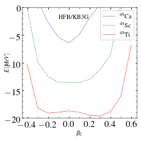

```python
plt.figure(figsize=(columnwidth,columnwidth))
item = 0
for df in dfs:
    plt.plot(df['bet2t'],df['Etot'],color=colors[item],linestyle=linestyles[item],label=dfs_tag[item])
    item +=1

plt.legend(fontsize=10)
plt.gca().xaxis.set_major_locator(ticker.MultipleLocator(0.2))
plt.gca().xaxis.set_minor_locator(ticker.MultipleLocator(0.1))

plt.gca().yaxis.set_major_locator(ticker.MultipleLocator(5))
plt.gca().yaxis.set_minor_locator(ticker.MultipleLocator(1))

plt.gca().yaxis.set_label_coords(-0.1,0.5)

plt.ylim(-20,0)

plt.xlabel(r'$\beta_2$')
plt.ylabel(r'$E [MeV]$')

plt.text(-0.1,-2,'HFB/KB3G')


plt.tight_layout()
plt.savefig('/Users/jmyao/Documents/WorkSpace/Talks/2019/src/GT/Ca_Sc_Ti_EHFB.eps');
```

# 48Ti

```python
Ti48_GCM56_wnp = pd.read_csv('Ti48/GCM.dat',sep=r'\s+')
Ti48_GCM56_wnp['iloc']=1
```

```python
Ti48_GCM56_wnp.head(20)
```

|  | J | i | E | E_ex | <beta> | <gamma> | Q_s | <N> | <Z> | rrms_p | acc1 | acc2 | iloc |
| --- | --- | --- | --- | --- | --- | --- | --- | --- | --- | --- | --- | --- | --- |
| 0 | 0 | 1 | -23.0803 | 0.0000 | 0.0713 | 0.0 | 0.0000 | 25.9994 | 21.9978 | 1.2227 | 0.0 | 0.0000 | 1 |
| 1 | 0 | 2 | -17.4838 | 5.5965 | 0.1547 | 0.0 | 0.0000 | 25.9987 | 21.9986 | 1.2229 | 0.0 | 0.0078 | 1 |
| 2 | 0 | 3 | -17.4750 | 5.6053 | -0.1616 | 0.0 | 0.0000 | 25.9980 | 21.9963 | 1.2223 | 0.0 | 0.0000 | 1 |
| 3 | 0 | 4 | -16.6203 | 6.4600 | 0.1245 | 0.0 | 0.0000 | 25.9937 | 21.9924 | 1.2211 | 0.0 | 0.0000 | 1 |
| 4 | 2 | 1 | -21.8789 | 1.2013 | 0.1744 | 0.0 | -5.8972 | 25.9997 | 21.9994 | 1.2231 | 0.0 | 0.0000 | 1 |
| 5 | 2 | 2 | -19.7040 | 3.3762 | -0.0941 | 0.0 | 1.5775 | 25.9981 | 21.9966 | 1.2223 | 0.0 | 0.0000 | 1 |
| 6 | 2 | 3 | -18.4274 | 4.6528 | 0.0573 | 0.0 | -0.2156 | 25.9934 | 21.9902 | 1.2205 | 0.0 | 0.0000 | 1 |
| 7 | 2 | 4 | -17.3217 | 5.7586 | -0.1182 | 0.0 | 5.1418 | 25.9973 | 21.9962 | 1.2222 | 0.0 | 0.0000 | 1 |
| 8 | 4 | 3 | -20.6060 | 2.4743 | 0.1949 | 0.0 | -7.7888 | 25.9995 | 21.9995 | 1.2231 | 0.0 | 0.0000 | 1 |
| 9 | 4 | 4 | -18.8405 | 4.2397 | 0.0472 | 0.0 | -2.8859 | 25.9977 | 21.9973 | 1.2225 | 0.0 | 0.0000 | 1 |
| 10 | 6 | 1 | -19.5648 | 3.5155 | 0.2146 | 0.0 | -10.7214 | 25.9994 | 21.9993 | 1.2231 | 0.0 | 0.0000 | 1 |
| 11 | 6 | 2 | -18.6976 | 4.3826 | -0.0673 | 0.0 | 2.9044 | 25.9977 | 21.9970 | 1.2224 | 0.0 | 0.0000 | 1 |
| 12 | 6 | 3 | -17.0830 | 5.9972 | 0.0843 | 0.0 | -5.7139 | 25.9967 | 21.9932 | 1.2214 | 0.0 | 0.0000 | 1 |
| 13 | 6 | 4 | -15.4868 | 7.5935 | 0.1392 | 0.0 | -6.7975 | 25.9964 | 21.9935 | 1.2215 | 0.0 | 0.0000 | 1 |

```python
def read_calc_data(filename):
    spectra=pd.read_csv(filename,delimiter='\s+',header=None)
    spectra.columns=['J','i','E','Ex','beta','gamma','Qs','N','Z','radius','acc1','acc2']
    spectra['idx']=spectra['i']/spectra['i']
    return spectra

def read_exp_data(filename):
    data=pd.read_csv(filename,delimiter='\s+',header=None)
    data.columns=['Ex']
    data['idx']=data['Ex']/data['Ex']
    return data

def plot_exp(data,shift):
    plt.scatter(data['x']+shift,data['Ex'],marker='_',s=800,c=data['J'],label=data['Jpi'])

def plot_spec(calc,shift):
    calc['x']=calc['N']/calc['N']
    plt.scatter(calc['x']+shift,calc['Ex'],marker='_',s=800,c=calc['J'])
    plt.tick_params(which='major', length=7, direction='in',labelsize=16)
    plt.xlim(-1.5,4)
    plt.ylim(-0.25,8)
    plt.ylabel('Excitation Energy [MeV]', fontsize=16)
    plt.xticks([]) #plt.xtick('off')
```

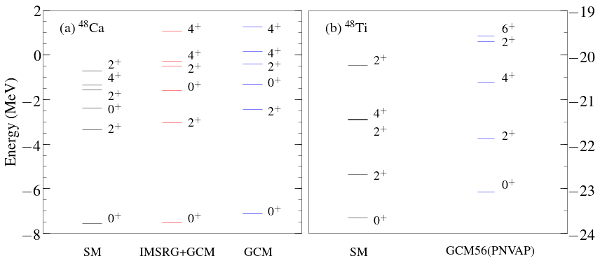

```python
SM4Ca=read_exp_data('old/SM4Ca48.dat')
SM4Ti=read_exp_data('old/SM4Ti48.dat')
GCM4CaH0=read_calc_data('old/GCM4Ca_KB3G.dat')
GCM4TiH0=read_calc_data('old/GCM4Ti_KB3G.dat')
GCM4CaH1=read_calc_data('old/GCM4Ca_KB3G-Ca48.dat')
GCM4TiH1=read_calc_data('old/GCM4Ti_KB3G-Ti48.dat')
plt.figure(figsize=(12,5))
plt.tight_layout()

plt.subplots_adjust(wspace = 0.0)



ax1 =plt.subplot(121)

ax1.yaxis.set_major_locator(ticker.MultipleLocator(2))
ax1.yaxis.set_minor_locator(ticker.MultipleLocator(0.5))

plt.xlim(-1.5,4)
plt.ylim(-8,2)

plt.text(0.95,-9,'SM',fontsize=18,fontweight='bold')
plt.text(1.3,-9,'IMSRG+GCM',fontsize=18,fontweight='bold')
plt.text(1.95,-9,'GCM',fontsize=18,fontweight='bold')

plt.scatter(SM4Ca['idx'],SM4Ca['Ex'],marker="_",s=800,color='black')
plt.scatter(GCM4CaH1['idx']+0.5,GCM4CaH1['E'],marker="_",s=800,color='red')
plt.scatter(GCM4CaH0['idx']+1,GCM4CaH0['E'],marker="_",s=800,color='blue')

plt.tick_params(which='major', length=7, direction='in',labelsize=16)
plt.ylabel('Energy (MeV)', fontsize=22,fontweight='bold')
plt.xticks([])

plt.text(0.8,1,r'(a) $^{48}$Ca',fontsize=20
    )

plt.text(1.1,-7.5,r'$0^+$',fontsize=fs)
plt.text(1.1,-3.5,r'$2^+$',fontsize=fs)
plt.text(1.1,-2.6,r'$0^+$',fontsize=fs)
plt.text(1.1,-2.0,r'$2^+$',fontsize=fs)
plt.text(1.1,-1.2,r'$4^+$',fontsize=fs)
plt.text(1.1,-0.6,r'$2^+$',fontsize=fs)

plt.text(1.6,-7.5,r'$0^+$',fontsize=fs)
plt.text(1.6,-3.2,r'$2^+$',fontsize=fs)
plt.text(1.6,-1.6,r'$0^+$',fontsize=fs)
plt.text(1.6,-0.8,r'$2^+$',fontsize=fs)
plt.text(1.6,-0.2,r'$4^+$',fontsize=fs)
plt.text(1.6, 1.0,r'$4^+$',fontsize=fs)

plt.text(2.1,-7.2,r'$0^+$',fontsize=fs)
plt.text(2.1,-2.7,r'$2^+$',fontsize=fs)
plt.text(2.1,-1.4,r'$0^+$',fontsize=fs)
plt.text(2.1,-0.7,r'$2^+$',fontsize=fs)
plt.text(2.1,-0.1,r'$4^+$',fontsize=fs)
plt.text(2.1, 1.0,r'$4^+$',fontsize=fs)
ax1.tick_params(which='major',direction='in',length=10,labelsize=22)
ax1.tick_params(which='minor',direction='in',length=5,labelsize=22)

plt.subplot(122,sharex=ax1)
plt.scatter(SM4Ti['idx'],SM4Ti['Ex'],marker="_",s=800,color='black')

# plt.scatter(GCM4TiH1['idx']+0.5,GCM4TiH1['E'],marker="_",s=800,color='red')
# plt.scatter(GCM4TiH0['idx']+1,GCM4TiH0['E'],marker="_",s=800,color='blue')



plt.scatter(Ti48_GCM56_wnp['iloc']+0.8,Ti48_GCM56_wnp['E'],
            color='blue', marker='_',s=600)




plt.tick_params(which='major', length=7, direction='in',labelsize=16)
plt.ylim(-24,-19)
plt.gca().yaxis.set_ticks_position('right')
plt.text(0.95,-24.5,'SM',fontsize=18,fontweight='bold')
#plt.text(1.3,-24.5,'IMSRG+GCM',fontsize=18,fontweight='bold')
plt.text(1.55,-24.5,'GCM56(PNVAP)',fontsize=18,fontweight='bold')

plt.text(0.8,-19.5,r'(b) $^{48}$Ti',fontsize=20
    )

plt.text(1.1,-23.8,r'$0^+$',fontsize=fs)
plt.text(1.1,-22.8,r'$2^+$',fontsize=fs)
plt.text(1.1,-21.8,r'$2^+$',fontsize=fs)
plt.text(1.1,-21.4,r'$4^+$',fontsize=fs)
plt.text(1.1,-20.2,r'$2^+$',fontsize=fs)

plt.text(1.9,-23,r'$0^+$',fontsize=fs)
plt.text(1.9,-21.9,r'$2^+$',fontsize=fs)
plt.text(1.9,-20.6,r'$4^+$',fontsize=fs)
plt.text(1.9,-19.8,r'$2^+$',fontsize=fs)
plt.text(1.9,-19.5,r'$6^+$',fontsize=fs)

# plt.text(2.1,-22.2,r'$0^+$',fontsize=fs)
# plt.text(2.1,-21.3,r'$2^+$',fontsize=fs)
# plt.text(2.1,-20.0,r'$4^+$',fontsize=fs)
# plt.text(2.1,-19.4,r'$2^+$',fontsize=fs)
plt.gca().tick_params(which='major',direction='in',length=10,labelsize=22)
plt.gca().tick_params(which='minor',direction='in',length=5,labelsize=22)

plt.gca().yaxis.set_major_locator(ticker.MultipleLocator(1))
plt.gca().yaxis.set_minor_locator(ticker.MultipleLocator(0.5))



#plt.title(r'GCM+AMP+PNVAP for $^{48}$Ti')
```

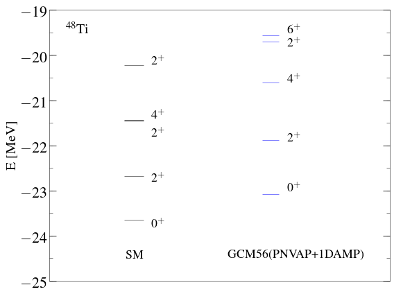

```python
plt.figure(figsize=(8,6))
plt.tight_layout()


plt.scatter(SM4Ti['idx'],SM4Ti['Ex'],marker="_",s=800,color='black')
plt.scatter(Ti48_GCM56_wnp['iloc']+0.8,Ti48_GCM56_wnp['E'],
            color='blue', marker='_',s=600)


plt.text(0.95,-24.5,'SM',fontsize=18,fontweight='bold')
plt.text(1.55,-24.5,'GCM56(PNVAP+1DAMP)',fontsize=18,fontweight='bold')


plt.text(1.1,-23.8,r'$0^+$',fontsize=fs)
plt.text(1.1,-22.8,r'$2^+$',fontsize=fs)
plt.text(1.1,-21.8,r'$2^+$',fontsize=fs)
plt.text(1.1,-21.4,r'$4^+$',fontsize=fs)
plt.text(1.1,-20.2,r'$2^+$',fontsize=fs)

plt.text(1.9,-23,r'$0^+$',fontsize=fs)
plt.text(1.9,-21.9,r'$2^+$',fontsize=fs)
plt.text(1.9,-20.6,r'$4^+$',fontsize=fs)
plt.text(1.9,-19.8,r'$2^+$',fontsize=fs)
plt.text(1.9,-19.5,r'$6^+$',fontsize=fs)


plt.gca().tick_params(which='major',direction='in',length=10,labelsize=22)
plt.gca().tick_params(which='minor',direction='in',length=5,labelsize=22)

plt.gca().yaxis.set_major_locator(ticker.MultipleLocator(1))
plt.gca().yaxis.set_minor_locator(ticker.MultipleLocator(0.5))

plt.ylim(-25,-19)
plt.xlim(0.5,2.5)
plt.xticks([])
plt.ylabel('E [MeV]', fontsize=20)

plt.text(0.6,-19.5,r'$^{48}$Ti', fontsize=20)


plt.tight_layout()
plt.savefig('/Users/jmyao/Documents/WorkSpace/Talks/2019/src/GT/Ti48_GCM.eps');
```

# Spectrum of 48Sc

```python
def HWG_Solution(HH,NN,k,option,style):
    """
        solution to the general eigenvalue equation:
        (HH - E * NN ) *f = 0

        - HH:  Hamiltonian kernel
        - NN:  Norm kernel
        - option: 'cutoff' or 'nos'
        - E :  eigenvalue
        - e.g.:
        """

    assert k>0

    Energy = []
    wfsgg  = []
    cutoffs= [1e-7,1e-6,1e-5,1e-4,1e-3,1e-2]
    count_states = []


    vals, vecs = scipy.linalg.eigh(NN)

    #print("The eigenvalues of norm:",vals)

    if option=='cutoff':
        for cutoff in cutoffs:
            basis      = vecs[:, vals >= cutoff]
            scale      = vals[vals >= cutoff]

            new_basis  = basis/np.sqrt(scale)[np.newaxis, :]
            matrix_natural = np.linalg.multi_dot((new_basis.T,HH,new_basis))
            E,gg = scipy.linalg.eigh(matrix_natural)

            Energy.append(E[k-1])
            wfsgg.append(gg)
        plt.plot(cutoffs,Energy,linestyle=style['linestyle'],c=style['color'])
        plt.tick_params(which='major',direction='in',length=10,labelsize=20)
        plt.tick_params(which='minor',direction='in',length=5,labelsize=20)
        plt.xscale('log')
        return Energy

    elif option =='nos':
        for num_states in range(k,len(vals)+1):  # at least k configurations
            basis      = vecs[:,-num_states:]
            scale      = vals[-num_states:]

            #print("nos={}".format(num_states))
            #print("eigvalues={}".format(scale))

            if(vals[-num_states:-num_states+1]<0):
                break

            #print("basis={}".format(basis))

            new_basis  = basis/np.sqrt(scale)[np.newaxis, :]
            #print("new_basis={}".format(new_basis))

            matrix_natural = np.linalg.multi_dot((new_basis.T,HH,new_basis))
            #print('{}'.format(matrix_natural))



            E,gg = scipy.linalg.eigh(matrix_natural)

            Energy.append(E[k-1])
            wfsgg.append(gg)
            count_states.append(num_states)
            #print("E={}".format(E))

        plt.plot(count_states,Energy,'-o',c=style['color'])
        plt.tick_params(which='major',direction='in',length=10,labelsize=20)
        plt.tick_params(which='minor',direction='in',length=5,labelsize=20)
        plt.gca().xaxis.set_major_locator(ticker.MultipleLocator(5))
        plt.gca().xaxis.set_minor_locator(ticker.MultipleLocator(1))
    else:
        print("Parameter [Option] should be nos/cutoff.")
```

```python
def df2matrix_int(df,col_idx1,col_idx2,col_matrix):
    """
        Convert a pandas DataFrame object to a numpy structured array.

        :df: the data frame to convert
        col_idx1   -- as row index
        col_idx2   -- as column index
        col_matrix -- as the matrix element
        :return:      matrix
        """
    dim    = int(np.sqrt(df.shape[0]))
    assert df.shape[0] == np.power(dim,2)
    matrix = df[col_matrix].as_matrix().reshape(dim,dim)

    for item,val in df.iterrows():
        idx1 = val[col_idx1] -1
        idx2 = val[col_idx2]-1
        value= val[col_matrix]


        matrix[idx1,idx2] = value
    return matrix
```

```python
data = pd.read_csv("./Sc48/kernels.dat",
                   delimiter=r'\s+',header=None)
```

```python
data.columns=['JJ','kpi','iq1','iq2','NN','HH']
```

```python
data['H/N'] = data['HH']/data['NN']
```

```python
# hhmat = df2matrix(dataJ0,'q1','q2','hh' )
# nnmat = df2matrix(dataJ0,'q1','q2','nn')

# nn_exact = nnmat
# hh_exact = hhmat


# HH1 = df2matrix_int(data,'iq1','iq2','HH' )
# NN1 = df2matrix_int(data,'iq1','iq2','NN')
```

```python
# plt.figure(figsize=(8,6))

# solution = HWG_Solution(HH1,NN1,1,'nos',redsolid)
# solution = HWG_Solution(HH1,NN1,2,'nos',reddash)
# solution = HWG_Solution(HH1,NN1,3,'nos',reddashdot)
# solution = HWG_Solution(HH1,NN1,4,'nos',reddot)


# set_figstyle(1,8,-14,5,'Number of States','E [MeV]')


# plt.gca().yaxis.set_major_locator(ticker.MultipleLocator(2))
# plt.gca().yaxis.set_minor_locator(ticker.MultipleLocator(1))


# plt.gca().xaxis.set_major_locator(ticker.MultipleLocator(2))
# plt.gca().xaxis.set_minor_locator(ticker.MultipleLocator(1))


# # plt.tight_layout()
# # plt.savefig('/Users/jmyao/Documents/WorkSpace/Papers/Manuscript_Preparation/2019/dbd/manuscript/GCM4Ti_N6hw16.eps');
```

# spectrum

```python
Sc48_spectrum       = pd.read_csv("./Sc48/spectrum_bet02.dat",delimiter=r'\s+')
Sc48_spectrum_bet00 = pd.read_csv("./Sc48/spectrum_bet00.dat",delimiter=r'\s+')
```

```python
Sc48_spectrum_bet00.dropna(axis=0,inplace=True)
```

```python
Sc48_spectrum_bet00['E'].min()
```

```
-12.2848
```

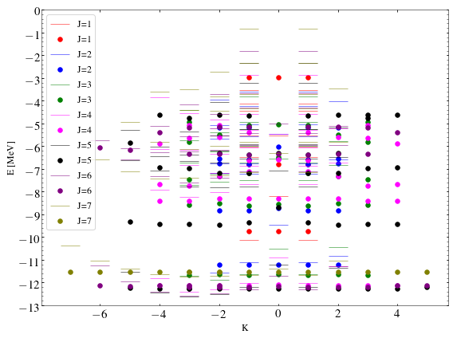

```python
colors=['pink','red','blue','green','magenta','black','purple','olive']
plt.figure(figsize=(8,6))
for J in range(1,8):
    c = colors[J]
    df  =Sc48_spectrum[Sc48_spectrum['J'] == J]
    df2  =Sc48_spectrum_bet00[Sc48_spectrum_bet00['J'] == J]
    plt.scatter(df['K'],df['E'],c=c,marker='_',s=600,label=r'J={}'.format(J))
    plt.scatter(df2['K'],df2['E'],c=c,marker='o',s=30,label=r'J={}'.format(J))


plt.ylim(-13,0)
plt.legend(fontsize=12)
plt.xlabel('K', fontsize=12)
plt.ylabel('E [MeV]', fontsize=12)

plt.gca().yaxis.set_major_locator(ticker.MultipleLocator(1))
plt.gca().yaxis.set_minor_locator(ticker.MultipleLocator(0.2))
```

```python
df_yrast = Sc48_spectrum[Sc48_spectrum['li']==1]
```

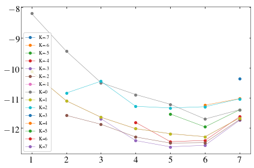

```python
for K in range(-7,8):
    df_yrast_K = df_yrast[df_yrast['K']==K]
    plt.plot(df_yrast_K['J'],df_yrast_K['E'],'-o',label=r'K={}'.format(K))

plt.legend()
```

# Shell-model calculation

```python
SM_Sc48_spectrum = pd.read_csv("./Sc48/SM_spec.dat",delimiter=r'\s+')
```

```python
SM_Sc48_spectrum['BGT']=SM_Sc48_spectrum['<1_m|GT|0>']**2*1.25**2*3
```

```python
SM_Sc48_spectrum.head()
```

|  | E_J=1 | <1_m\|GT\|0> | BGT |
| --- | --- | --- | --- |
| 0 | -11.37690 | 0.291479 | 0.398249 |
| 1 | -10.92808 | -0.075800 | 0.026933 |
| 2 | -10.44374 | 0.101200 | 0.048007 |
| 3 | -9.94554 | -0.038900 | 0.007093 |
| 4 | -9.44469 | 0.024000 | 0.002700 |

```python
SM_Sc48_spectrum.head()
```

|  | E_J=1 | <1_m\|GT\|0> | BGT |
| --- | --- | --- | --- |
| 0 | -11.37690 | 0.291479 | 0.398249 |
| 1 | -10.92808 | -0.075800 | 0.026933 |
| 2 | -10.44374 | 0.101200 | 0.048007 |
| 3 | -9.94554 | -0.038900 | 0.007093 |
| 4 | -9.44469 | 0.024000 | 0.002700 |

```python
# plt.figure(figsize=(8,6))

# for k in range(1,10):
#     solution = HWG_Solution(HHJ1,NNJ1,k,'nos',bluesolid)



# set_figstyle(1,20,-10.5,-4,'Number of States','E [MeV]')


# plt.gca().yaxis.set_major_locator(ticker.MultipleLocator(2))
# plt.gca().yaxis.set_minor_locator(ticker.MultipleLocator(1))


# plt.gca().xaxis.set_major_locator(ticker.MultipleLocator(2))
# plt.gca().xaxis.set_minor_locator(ticker.MultipleLocator(1))
```

# 42Ca-Sc-Ti

```python
GCM4Ca42 = pd.read_csv('Ca42/GCM.dat',sep=r'\s+')
GCM4Sc42 = pd.read_csv('Sc42/GCM.dat',sep=r'\s+')
GCM4Ti42 = pd.read_csv('Ti42/GCM.dat',sep=r'\s+')
```

```python
GCM4Ca42
```

|  | J | i | E | E_ex | <beta> | <gamma> | Q_s | <N> | <Z> | rrms_p | acc1 | acc2 |
| --- | --- | --- | --- | --- | --- | --- | --- | --- | --- | --- | --- | --- |
| 0 | 0 | 1 | -2.5464 | 0.0000 | 0.0370 | 0.0 | 0.0 | 22.0 | 20.0 | NaN | 0.0 | 0.0 |
| 1 | 0 | 2 | 3.2246 | 5.7710 | 0.0630 | 0.0 | 0.0 | 22.0 | 20.0 | NaN | 0.0 | 0.0 |
| 2 | 2 | 1 | -0.8253 | 1.7211 | 0.1000 | 0.0 | 0.0 | 22.0 | 20.0 | NaN | 0.0 | 0.0 |
| 3 | 2 | 2 | 0.0000 | 2.5464 | 0.4992 | 0.0 | 0.0 | 0.0 | 0.0 | NaN | 0.0 | 0.0 |
| 4 | 4 | 1 | -0.0646 | 2.4818 | 0.1000 | 0.0 | 0.0 | 22.0 | 20.0 | NaN | 0.0 | 0.0 |
| 5 | 4 | 2 | 0.0000 | 2.5464 | 4.5574 | 0.0 | 0.0 | 0.0 | 0.0 | NaN | 0.0 | 0.0 |
| 6 | 6 | 1 | 0.2177 | 2.7641 | 0.1000 | 0.0 | 0.0 | 22.0 | 20.0 | 0.0 | 0.0 | 0.0 |
| 7 | 6 | 2 | 0.0000 | 2.5464 | 1107.8725 | 0.0 | 0.0 | 0.0 | 0.0 | NaN | 0.0 | 0.0 |

```python
Sc42_SM_J1 = pd.read_csv('Sc42/BGT_Ca2Sc.dat',delimiter=r'\s+')
Sc42_SM_J1['BGTs']=Sc42_SM_J1['M_GT']**2
Sc42_SM_J1['BGTs2'] = Sc42_SM_J1['BGTs']*3*2
```

```python
Sc42_SM_J1.head()
```

|  | EJ1 | M_GT | BGTs | BGTs2 |
| --- | --- | --- | --- | --- |
| 0 | -2.349736 | 0.873858 | 0.763628 | 4.581767 |
| 1 | 1.419307 | 0.159428 | 0.025417 | 0.152504 |
| 2 | 3.931656 | 0.160835 | 0.025868 | 0.155207 |
| 3 | 5.214402 | 0.141246 | 0.019950 | 0.119703 |
| 4 | 6.375787 | 0.367378 | 0.134967 | 0.809800 |

```python
Sc42_SM_J1['BGTs2'].sum()
```

```
6.0000054353220005
```

```python
BGT_GCM_beta00= pd.read_csv('Sc42/BGT_Ca2Sc_GCM2beta00.dat',delimiter=r'\s+')
BGT_GCM_beta01= pd.read_csv('Sc42/BGT_Ca2Sc_GCM2beta01.dat',delimiter=r'\s+')
```

```python
BGT_GCM_beta00['BGTs2'] = BGT_GCM_beta00['BGT(0^+->1^+_m)']
BGT_GCM_beta01['BGTs2'] = BGT_GCM_beta01['BGT(0^+->1^+_m)']
```

```python
BGT_GCM_beta01.head()
```

|  | 1^+_m | E[MeV] | M_GT(final) | BGT(0^+->1^+_m) | BGTs2 |
| --- | --- | --- | --- | --- | --- |
| 0 | 1 | -2.17954 | 2.116084 | 4.477810 | 4.477810 |
| 1 | 2 | 1.55697 | -0.422720 | 0.178692 | 0.178692 |
| 2 | 3 | 3.98730 | -0.407739 | 0.166251 | 0.166251 |
| 3 | 4 | 5.24881 | 0.344054 | 0.118373 | 0.118373 |
| 4 | 5 | 6.37713 | -0.915822 | 0.838729 | 0.838729 |

```python
BGT_GCM_beta01['BGT(0^+->1^+_m)'].sum()
```

```
5.999982999999999
```

```python
BGT_GCM_beta00.head()
```

|  | 1^+_m | E[MeV] | M_GT(final) | BGT(0^+->1^+_m) |
| --- | --- | --- | --- | --- |
| 0 | 1 | -2.17952 | 2.116084 | 4.477812 |
| 1 | 2 | 1.55695 | 0.422727 | 0.178698 |
| 2 | 3 | 3.98725 | -0.407746 | 0.166257 |
| 3 | 4 | 5.24874 | 0.344049 | 0.118369 |
| 4 | 5 | 6.37704 | -0.915843 | 0.838768 |

```python
BGT_GCM_beta00['BGT(0^+->1^+_m)'].sum()
```

```
5.999979000000001
```

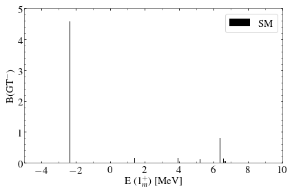

```python
plt.bar(Sc42_SM_J1['EJ1'],Sc42_SM_J1['BGTs2'],color='k', width=0.05,label='SM')


plt.xlabel(r'E ($1^+_m$) [MeV]',fontsize=15)
plt.ylabel(r'B(GT$^-$)',fontsize=15)
plt.xlim(-5,10)
plt.ylim(0,5)
plt.legend(fontsize=15)
#plt.title(r'$^{42}$Ca($0^+_1, {\rm sph})$ $\to ^{42}$Sc($1^+_m, \beta_2)$',fontsize=15)


plt.gca().yaxis.set_major_locator(ticker.MultipleLocator(1))
plt.gca().yaxis.set_minor_locator(ticker.MultipleLocator(0.2))


plt.gca().xaxis.set_major_locator(ticker.MultipleLocator(2))
plt.gca().xaxis.set_minor_locator(ticker.MultipleLocator(1))

plt.tight_layout()
```

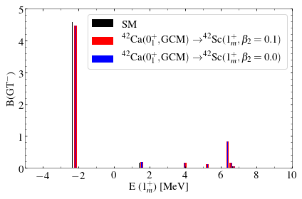

```python
plt.bar(Sc42_SM_J1['EJ1'],Sc42_SM_J1['BGTs2'],color='k', width=0.05,label='SM')
plt.bar(BGT_GCM_beta01['E[MeV]'],BGT_GCM_beta01['BGT(0^+->1^+_m)'],color='red',
        width=0.15,label=r'$^{42}$Ca($0^+_1, {\rm GCM})$ $\to ^{42}$Sc($1^+_m, \beta_2=0.1)$')
plt.bar(BGT_GCM_beta01['E[MeV]'],BGT_GCM_beta01['BGT(0^+->1^+_m)'],color='blue',
        width=0.05,label=r'$^{42}$Ca($0^+_1, {\rm GCM})$ $\to ^{42}$Sc($1^+_m, \beta_2=0.0)$')



plt.xlabel(r'E ($1^+_m$) [MeV]',fontsize=15)
plt.ylabel(r'B(GT$^-$)',fontsize=15)
plt.xlim(-5,10)
plt.ylim(0,5)
plt.legend(fontsize=15)
#plt.title(r'$^{42}$Ca($0^+_1, {\rm sph})$ $\to ^{42}$Sc($1^+_m, \beta_2)$',fontsize=15)


plt.gca().yaxis.set_major_locator(ticker.MultipleLocator(1))
plt.gca().yaxis.set_minor_locator(ticker.MultipleLocator(0.2))


plt.gca().xaxis.set_major_locator(ticker.MultipleLocator(2))
plt.gca().xaxis.set_minor_locator(ticker.MultipleLocator(1))

plt.tight_layout()
plt.savefig('/Users/jmyao/Documents/WorkSpace/Talks/2019/src/GT/Sc42_BGT_GCM2beta.eps');
```

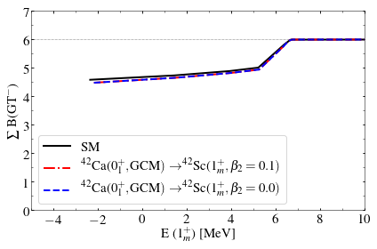

```python
plt.plot(Sc42_SM_J1['EJ1'],np.cumsum(Sc42_SM_J1['BGTs2']),'-',linewidth=2,color='k', label='SM')
plt.plot(BGT_GCM_beta01['E[MeV]'],np.cumsum(BGT_GCM_beta01['BGT(0^+->1^+_m)']),'-.',
         linewidth=2,color='red',
        label=r'$^{42}$Ca($0^+_1, {\rm GCM})$ $\to ^{42}$Sc($1^+_m, \beta_2=0.1)$')
plt.plot(BGT_GCM_beta01['E[MeV]'],np.cumsum(BGT_GCM_beta01['BGT(0^+->1^+_m)']),'--',
         color='blue',linewidth=2,
        label=r'$^{42}$Ca($0^+_1, {\rm GCM})$ $\to ^{42}$Sc($1^+_m, \beta_2=0.0)$')


plt.xlabel(r'E ($1^+_m$) [MeV]',fontsize=15)
plt.ylabel(r'$\sum$ B(GT$^-$)',fontsize=15)
plt.xlim(-5,10)
plt.ylim(0,7)
plt.legend(fontsize=15)

plt.axhline(6,linestyle=':',c='k')

plt.gca().yaxis.set_major_locator(ticker.MultipleLocator(1))
plt.gca().yaxis.set_minor_locator(ticker.MultipleLocator(0.5))


plt.gca().xaxis.set_major_locator(ticker.MultipleLocator(2))
plt.gca().xaxis.set_minor_locator(ticker.MultipleLocator(1))

plt.tight_layout()
plt.savefig('/Users/jmyao/Documents/WorkSpace/Talks/2019/src/GT/Sc42_BGT_Sum.eps');
```

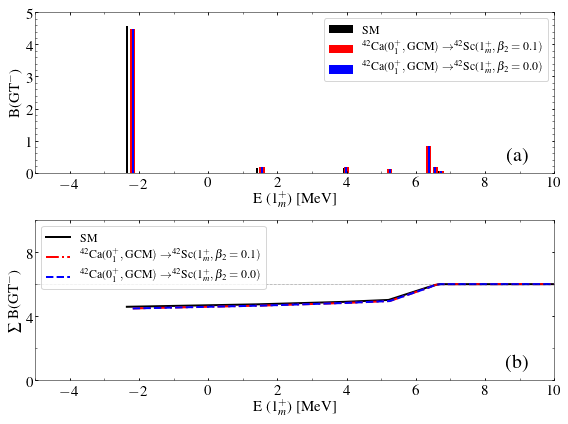

```python
plt.subplots(2, 2, sharex=True, sharey=False, figsize=(8,6))

plt.subplot(2,1,1)

plt.bar(Sc42_SM_J1['EJ1'],Sc42_SM_J1['BGTs2'],color='k', width=0.05,label='SM')
plt.bar(BGT_GCM_beta01['E[MeV]'],BGT_GCM_beta01['BGT(0^+->1^+_m)'],color='red',
        width=0.15,label=r'$^{42}$Ca($0^+_1, {\rm GCM})$ $\to ^{42}$Sc($1^+_m, \beta_2=0.1)$')
plt.bar(BGT_GCM_beta01['E[MeV]'],BGT_GCM_beta01['BGT(0^+->1^+_m)'],color='blue',
        width=0.05,label=r'$^{42}$Ca($0^+_1, {\rm GCM})$ $\to ^{42}$Sc($1^+_m, \beta_2=0.0)$')




plt.xlabel(r'E ($1^+_m$) [MeV]',fontsize=15)
plt.ylabel(r'B(GT$^-$)',fontsize=15)
plt.xlim(-5,10)
plt.ylim(0,5)
plt.legend(fontsize=12)


plt.gca().yaxis.set_major_locator(ticker.MultipleLocator(1))
plt.gca().yaxis.set_minor_locator(ticker.MultipleLocator(0.2))


plt.gca().xaxis.set_major_locator(ticker.MultipleLocator(2))
plt.gca().xaxis.set_minor_locator(ticker.MultipleLocator(1))


plt.text(0.95,0.05,'(a)',fontsize=20,
         transform=plt.gca().transAxes, ha='right', va='bottom')

plt.subplot(2,1,2)



plt.plot(Sc42_SM_J1['EJ1'],np.cumsum(Sc42_SM_J1['BGTs2']),'-',linewidth=2,color='k', label='SM')
plt.plot(BGT_GCM_beta01['E[MeV]'],np.cumsum(BGT_GCM_beta01['BGT(0^+->1^+_m)']),'-.',
         linewidth=2,color='red',
        label=r'$^{42}$Ca($0^+_1, {\rm GCM})$ $\to ^{42}$Sc($1^+_m, \beta_2=0.1)$')
plt.plot(BGT_GCM_beta01['E[MeV]'],np.cumsum(BGT_GCM_beta01['BGT(0^+->1^+_m)']),'--',
         color='blue',linewidth=2,
        label=r'$^{42}$Ca($0^+_1, {\rm GCM})$ $\to ^{42}$Sc($1^+_m, \beta_2=0.0)$')


plt.xlabel(r'E ($1^+_m$) [MeV]',fontsize=15)
plt.ylabel(r'$\sum$ B(GT$^-$)',fontsize=15)
plt.xlim(-5,10)
plt.ylim(0,10)

plt.legend(loc=2,fontsize=12)

plt.axhline(6,linestyle=':',c='k')

plt.gca().yaxis.set_major_locator(ticker.MultipleLocator(4))
plt.gca().yaxis.set_minor_locator(ticker.MultipleLocator(2))


plt.gca().xaxis.set_major_locator(ticker.MultipleLocator(2))
plt.gca().xaxis.set_minor_locator(ticker.MultipleLocator(1))

plt.text(0.95,0.05,'(b)',fontsize=20,
         transform=plt.gca().transAxes, ha='right', va='bottom')

plt.tight_layout()
plt.savefig('/Users/jmyao/Documents/WorkSpace/Talks/2019/src/GT/Sc42_BGT_Sum.eps');
```

```python
Sc42_SM_J1.head()
```

[output not shown]

```python
BGT_GCM_beta01.head()
```

|  | 1^+_m | E[MeV] | M_GT(final) | BGT(0^+->1^+_m) | BGTs2 |
| --- | --- | --- | --- | --- | --- |
| 0 | 1 | -2.17954 | 2.116084 | 4.477810 | 4.477810 |
| 1 | 2 | 1.55697 | -0.422720 | 0.178692 | 0.178692 |
| 2 | 3 | 3.98730 | -0.407739 | 0.166251 | 0.166251 |
| 3 | 4 | 5.24881 | 0.344054 | 0.118373 | 0.118373 |
| 4 | 5 | 6.37713 | -0.915822 | 0.838729 | 0.838729 |

```python
bins = 0.13
Ca2ScA42_SM_LR = folding_lorentzian(1.0,0.13,bins, Sc42_SM_J1['EJ1'],Sc42_SM_J1['BGTs2'],['EJ1','BGT'])
Ca2ScA42_GCM_LR = folding_lorentzian(1.0,0.13,bins, BGT_GCM_beta01['E[MeV]'],BGT_GCM_beta01['BGTs2'],['EJ1','BGT'])
```

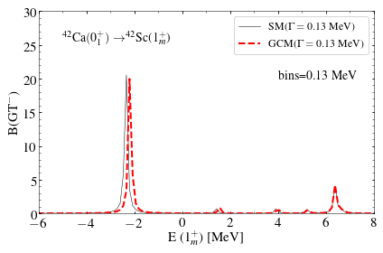

```python
plt.plot(Ca2ScA42_SM_LR['EJ1'],Ca2ScA42_SM_LR['BGT'],'-',
         color='k', label=r'SM($\Gamma=0.13$ MeV)')

plt.plot(Ca2ScA42_GCM_LR['EJ1'],Ca2ScA42_GCM_LR['BGT'],'--',
         color='r',linewidth=2,label=r'GCM($\Gamma=0.13$ MeV)')

# plt.bar(Sc42_SM_J1['EJ1'],Sc42_SM_J1['BGTs2'],color='k', width=0.05,label='SM')
# plt.bar(BGT_GCM_beta01['E[MeV]'],BGT_GCM_beta01['BGT(0^+->1^+_m)'],color='red',
#         width=0.15,label=r'$^{42}$Ca($0^+_1, {\rm GCM})$ $\to ^{42}$Sc($1^+_m, \beta_2=0.1)$')



plt.xlabel(r'E ($1^+_m$) [MeV]',fontsize=15)
plt.ylabel(r'B(GT$^-$)',fontsize=15)
plt.xlim(-6,8)
plt.ylim(0,30)
plt.legend(fontsize=12)


plt.gca().yaxis.set_major_locator(ticker.MultipleLocator(5))
plt.gca().yaxis.set_minor_locator(ticker.MultipleLocator(1))


plt.gca().xaxis.set_major_locator(ticker.MultipleLocator(2))
plt.gca().xaxis.set_minor_locator(ticker.MultipleLocator(1))

plt.tight_layout()

plt.text(-5,25,r'$^{42}$Ca$(0^+_1)$ $\to ^{42}$Sc($1^+_m$)',fontsize=14)

plt.text(4,20,'bins=0.13 MeV',fontsize=14)

plt.savefig('/Users/jmyao/Documents/WorkSpace/Talks/2019/src/GT/Sc42_BGT_Lorentzian.eps');
```

```python
Ca2ScA42_GCM_LR['BGT'].sum()*0.1
```

```
6.001275482171607
```

```python
Sc42_SM_J1['iloc']=-1
BGT_GCM_beta00['iloc']=0
BGT_GCM_beta01['iloc']=1
```

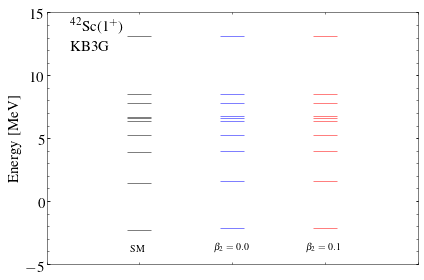

```python
plt.scatter(Sc42_SM_J1['iloc'], Sc42_SM_J1['EJ1'],
            c='k',marker='_',s=600,label=r'SM')


plt.scatter(BGT_GCM_beta00['iloc'], BGT_GCM_beta00['E[MeV]'],
            c='blue',marker='_',s=600,label=r'$\beta_2$=0.0')

plt.scatter(BGT_GCM_beta01['iloc'], BGT_GCM_beta01['E[MeV]'],
            c='red',marker='_',s=600,label=r'$\beta_2$=0.1')



plt.gca().yaxis.set_major_locator(ticker.MultipleLocator(5))
plt.gca().yaxis.set_minor_locator(ticker.MultipleLocator(1))


plt.gca().xaxis.set_major_locator(ticker.MultipleLocator(1))
plt.gca().xaxis.set_minor_locator(ticker.MultipleLocator(1))

plt.xticks([])

plt.ylabel('Energy [MeV]', fontsize=15)
plt.text(-1.75,13.5,r'$^{42}$Sc($1^+$)',fontsize=15)

plt.text(-1.75,12,r'KB3G',fontsize=15)

plt.text(-1.1,-4,'SM')
plt.text(-0.2,-4,r'$\beta_2=0.0$')
plt.text(0.8,-4,r'$\beta_2=0.1$')


plt.xlim(-2,2)
plt.ylim(-5,15)

plt.tight_layout()
#plt.savefig('/Users/jmyao/Documents/WorkSpace/Talks/2019/src/GT/Sc42_EJ1.eps');
```

# Sc44

```python
Sc44_SM_J1 = read_data('energy.dat','MGT.dat')
```

```python
Sc44_SM_J1['BGTs'].sum() # should be 3*(N-Z)=3*4=12
```

```
0.9999995285369999
```

```python
Sc44_SM_J1['BGTs2'] = Sc44_SM_J1['BGTs']*3*4
```

```python
Sc44_SM_J1.head()
```

|  | EJ1 | MGTs | BGTs | BGTs2 |
| --- | --- | --- | --- | --- |
| 0 | -7.458007 | -0.362075 | 0.131098 | 1.573180 |
| 1 | -5.566460 | -0.226287 | 0.051206 | 0.614470 |
| 2 | -4.398257 | 0.503013 | 0.253022 | 3.036265 |
| 3 | -3.797109 | -0.042265 | 0.001786 | 0.021436 |
| 4 | -3.426403 | -0.106125 | 0.011263 | 0.135150 |

```python
Sc44_BGT_GCM_beta00= pd.read_csv('Sc44/BGT_Ca2Sc_GCM2beta00.dat',delimiter=r'\s+')
Sc44_BGT_GCM_beta01= pd.read_csv('Sc44/BGT_Ca2Sc_GCM2beta01.dat',delimiter=r'\s+')
Sc44_BGT_GCM_beta02= pd.read_csv('Sc44/BGT_Ca2Sc_GCM2beta02.dat',delimiter=r'\s+')
```

```python
Sc44_BGT_GCM_beta02.head()
```

|  | 1^+_m | E[MeV] | M_GT(final) | BGT(0^+->1^+_m) |
| --- | --- | --- | --- | --- |
| 0 | 1 | -7.11175 | 1.225906 | 1.502847 |
| 1 | 2 | -5.22017 | -1.053373 | 1.109595 |
| 2 | 3 | -4.02149 | -1.696468 | 2.878002 |
| 3 | 4 | -3.42635 | 0.038581 | 0.001489 |
| 4 | 5 | -3.12670 | 0.228822 | 0.052360 |

```python
Sc44_BGT_GCM_beta01.head()
```

|  | 1^+_m | E[MeV] | M_GT(final) | BGT(0^+->1^+_m) |
| --- | --- | --- | --- | --- |
| 0 | 1 | -7.08876 | -1.241385 | 1.541038 |
| 1 | 2 | -5.23300 | 1.089547 | 1.187113 |
| 2 | 3 | -3.90246 | -1.683075 | 2.832740 |
| 3 | 4 | -3.39921 | 0.385626 | 0.148707 |
| 4 | 5 | -3.11126 | 0.215524 | 0.046451 |

```python
Sc44_BGT_GCM_beta02['BGT(0^+->1^+_m)'].sum()
```

```
11.905088
```

```python
Sc44_BGT_GCM_beta01['BGT(0^+->1^+_m)'].sum()
```

```
11.788130999999998
```

```python
Sc44_BGT_GCM_beta00.head()
```

|  | 1^+_m | E[MeV] | M_GT(final) | BGT(0^+->1^+_m) |
| --- | --- | --- | --- | --- |
| 0 | 1 | -4.79684 | 2.652578 | 7.036169 |
| 1 | 2 | -2.10846 | 0.868059 | 0.753526 |
| 2 | 3 | 0.42545 | -0.652966 | 0.426365 |
| 3 | 4 | 1.73835 | 0.406572 | 0.165301 |
| 4 | 5 | 2.43161 | -1.848476 | 3.416862 |

```
<BarContainer object of 10 artists>
```

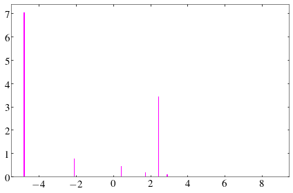

```python
plt.bar(Sc44_BGT_GCM_beta00['E[MeV]'],Sc44_BGT_GCM_beta00['BGT(0^+->1^+_m)'],color='magenta',
        width=0.05,label=r'$^{44}$Ca($0^+_1, {\rm GCM})$ $\to ^{44}$Sc($1^+_m, \beta_2=0.0)$')
```

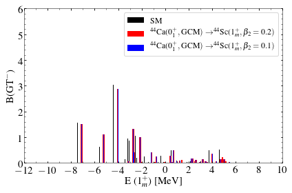

```python
plt.bar(Sc44_SM_J1['EJ1'],Sc44_SM_J1['BGTs2'],color='k', width=0.05,label='SM')
plt.bar(Sc44_BGT_GCM_beta02['E[MeV]'],Sc44_BGT_GCM_beta02['BGT(0^+->1^+_m)'],color='red',
        width=0.15,label=r'$^{44}$Ca($0^+_1, {\rm GCM})$ $\to ^{44}$Sc($1^+_m, \beta_2=0.2)$')


plt.bar(Sc44_BGT_GCM_beta02['E[MeV]'],Sc44_BGT_GCM_beta02['BGT(0^+->1^+_m)'],color='blue',
        width=0.05,label=r'$^{44}$Ca($0^+_1, {\rm GCM})$ $\to ^{44}$Sc($1^+_m, \beta_2=0.1)$')





plt.xlabel(r'E ($1^+_m$) [MeV]',fontsize=15)
plt.ylabel(r'B(GT$^-$)',fontsize=15)
plt.xlim(-12,10)
plt.ylim(0,6)
plt.legend(fontsize=12)


plt.gca().yaxis.set_major_locator(ticker.MultipleLocator(1))
plt.gca().yaxis.set_minor_locator(ticker.MultipleLocator(0.2))


plt.gca().xaxis.set_major_locator(ticker.MultipleLocator(2))
plt.gca().xaxis.set_minor_locator(ticker.MultipleLocator(1))

plt.tight_layout()
plt.savefig('/Users/jmyao/Documents/WorkSpace/Talks/2019/src/GT/Sc44_BGT_GCM2beta.eps');
```

```python
Sc44_SM_J1['iloc']=-1
Sc44_BGT_GCM_beta00['iloc']=0
Sc44_BGT_GCM_beta01['iloc']=1
Sc44_BGT_GCM_beta02['iloc']=2
```

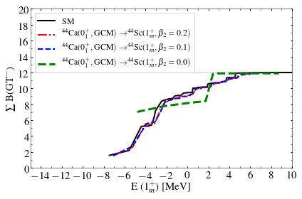

```python
plt.plot(Sc44_SM_J1['EJ1'],np.cumsum(Sc44_SM_J1['BGTs2']),'-',
         linewidth=2, color='k',  label='SM')

plt.plot(Sc44_BGT_GCM_beta02['E[MeV]'],np.cumsum(Sc44_BGT_GCM_beta02['BGT(0^+->1^+_m)']),'-.',color='red',
        linewidth=2,label=r'$^{44}$Ca($0^+_1, {\rm GCM})$ $\to ^{44}$Sc($1^+_m, \beta_2=0.2)$')
plt.plot(Sc44_BGT_GCM_beta01['E[MeV]'],np.cumsum(Sc44_BGT_GCM_beta01['BGT(0^+->1^+_m)']),'--',color='blue',
         linewidth=2,label=r'$^{44}$Ca($0^+_1, {\rm GCM})$ $\to ^{44}$Sc($1^+_m, \beta_2=0.1)$')

plt.plot(Sc44_BGT_GCM_beta00['E[MeV]'],np.cumsum(Sc44_BGT_GCM_beta00['BGT(0^+->1^+_m)']),'--',color='green',
         linewidth=3,label=r'$^{44}$Ca($0^+_1, {\rm GCM})$ $\to ^{44}$Sc($1^+_m, \beta_2=0.0)$')

plt.xlabel(r'E ($1^+_m$) [MeV]',fontsize=15)
plt.ylabel(r'$\sum$ B(GT$^-$)',fontsize=15)
plt.xlim(-15,10)
plt.ylim(0,20)
plt.legend(loc=2,fontsize=12)

plt.axhline(12,linestyle=':',c='k')

plt.gca().yaxis.set_major_locator(ticker.MultipleLocator(2))
plt.gca().yaxis.set_minor_locator(ticker.MultipleLocator(1))


plt.gca().xaxis.set_major_locator(ticker.MultipleLocator(2))
plt.gca().xaxis.set_minor_locator(ticker.MultipleLocator(1))

plt.tight_layout()
plt.savefig('/Users/jmyao/Documents/WorkSpace/Talks/2019/src/GT/Sc44_BGT_Sum.eps');
```

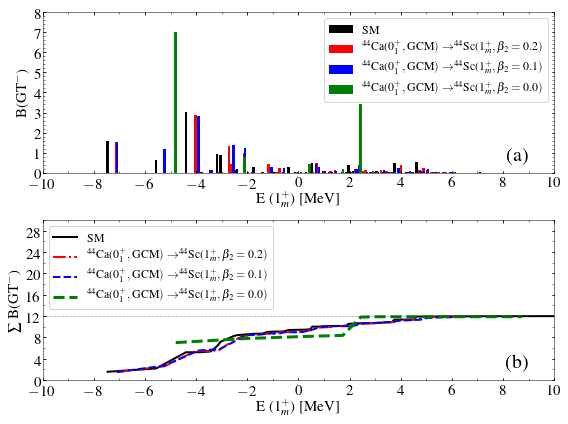

```python
plt.subplots(2, 2, sharex=True, sharey=False, figsize=(8,6))

plt.subplot(2,1,1)


plt.bar(Sc44_SM_J1['EJ1'],Sc44_SM_J1['BGTs2'],color='k', width=0.1,label='SM')
plt.bar(Sc44_BGT_GCM_beta02['E[MeV]'],Sc44_BGT_GCM_beta02['BGT(0^+->1^+_m)'],color='red',
        width=0.1,label=r'$^{44}$Ca($0^+_1, {\rm GCM})$ $\to ^{44}$Sc($1^+_m, \beta_2=0.2)$')


plt.bar(Sc44_BGT_GCM_beta01['E[MeV]'],Sc44_BGT_GCM_beta01['BGT(0^+->1^+_m)'],color='blue',
        width=0.1,label=r'$^{44}$Ca($0^+_1, {\rm GCM})$ $\to ^{44}$Sc($1^+_m, \beta_2=0.1)$')


plt.bar(Sc44_BGT_GCM_beta00['E[MeV]'],Sc44_BGT_GCM_beta00['BGT(0^+->1^+_m)'],color='green',
        width=0.1,label=r'$^{44}$Ca($0^+_1, {\rm GCM})$ $\to ^{44}$Sc($1^+_m, \beta_2=0.0)$')



plt.xlabel(r'E ($1^+_m$) [MeV]',fontsize=15)
plt.ylabel(r'B(GT$^-$)',fontsize=15)
plt.xlim(-10,10)
plt.ylim(0,8)
plt.legend(fontsize=12)


plt.gca().yaxis.set_major_locator(ticker.MultipleLocator(1))
plt.gca().yaxis.set_minor_locator(ticker.MultipleLocator(0.2))


plt.gca().xaxis.set_major_locator(ticker.MultipleLocator(2))
plt.gca().xaxis.set_minor_locator(ticker.MultipleLocator(1))


plt.text(0.95,0.05,'(a)',fontsize=20,
         transform=plt.gca().transAxes, ha='right', va='bottom')

plt.subplot(2,1,2)


plt.plot(Sc44_SM_J1['EJ1'],np.cumsum(Sc44_SM_J1['BGTs2']),'-',
         linewidth=2, color='k',  label='SM')

plt.plot(Sc44_BGT_GCM_beta02['E[MeV]'],np.cumsum(Sc44_BGT_GCM_beta02['BGT(0^+->1^+_m)']),'-.',color='red',
        linewidth=2,label=r'$^{44}$Ca($0^+_1, {\rm GCM})$ $\to ^{44}$Sc($1^+_m, \beta_2=0.2)$')

plt.plot(Sc44_BGT_GCM_beta01['E[MeV]'],np.cumsum(Sc44_BGT_GCM_beta01['BGT(0^+->1^+_m)']),'--',color='blue',
         linewidth=2,label=r'$^{44}$Ca($0^+_1, {\rm GCM})$ $\to ^{44}$Sc($1^+_m, \beta_2=0.1)$')

plt.plot(Sc44_BGT_GCM_beta00['E[MeV]'],np.cumsum(Sc44_BGT_GCM_beta00['BGT(0^+->1^+_m)']),'--',color='green',
         linewidth=3,label=r'$^{44}$Ca($0^+_1, {\rm GCM})$ $\to ^{44}$Sc($1^+_m, \beta_2=0.0)$')

plt.xlabel(r'E ($1^+_m$) [MeV]',fontsize=15)
plt.ylabel(r'$\sum$ B(GT$^-$)',fontsize=15)
plt.xlim(-10,10)
plt.ylim(0,30)

plt.legend(loc=2,fontsize=12)

plt.axhline(12,linestyle=':',c='k')

plt.gca().yaxis.set_major_locator(ticker.MultipleLocator(4))
plt.gca().yaxis.set_minor_locator(ticker.MultipleLocator(2))


plt.gca().xaxis.set_major_locator(ticker.MultipleLocator(2))
plt.gca().xaxis.set_minor_locator(ticker.MultipleLocator(1))

plt.text(0.95,0.05,'(b)',fontsize=20,
         transform=plt.gca().transAxes, ha='right', va='bottom')

plt.tight_layout()
plt.savefig('/Users/jmyao/Documents/WorkSpace/Talks/2019/src/GT/Sc44_BGT_Sum.eps');
```

```python
bins = 0.1
E_BGT_df = folding_lorentzian(1.0,0.13,bins, Sc44_SM_J1)
```

```python
E_BGT_df.head()
```

|  | EJ1 | BGT |
| --- | --- | --- |
| 0 | -10.0 | 0.009614 |
| 1 | -9.9 | 0.010188 |
| 2 | -9.8 | 0.010825 |
| 3 | -9.7 | 0.011537 |
| 4 | -9.6 | 0.012335 |

```python
scale = E_BGT_df['BGT'].sum()*bins/Sc44_SM_J1['BGTs2'].sum() #12
```

```python
scale
```

```
0.9944822732173764
```

```
Text(0,5.2,'$^{44}$Ca$(0^+_1)$ $\\to ^{44}$Sc($1^+_m$)')
```

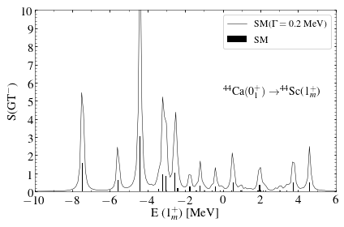

```python
bins = 0.1
E_BGT_df = folding_lorentzian(1.0,0.13,bins, Sc44_SM_J1)



plt.bar(Sc44_SM_J1['EJ1'],Sc44_SM_J1['BGTs2'],color='k', width=0.05,label='SM')
plt.plot(E_BGT_df['EJ1'],E_BGT_df['BGT'],color='k', label=r'SM($\Gamma=0.2$ MeV)')

plt.xlabel(r'E ($1^+_m$) [MeV]',fontsize=15)
plt.ylabel(r'S(GT$^-$)',fontsize=15)
plt.xlim(-10,6)
plt.ylim(0,10)
plt.legend(fontsize=12)


plt.gca().yaxis.set_major_locator(ticker.MultipleLocator(1))
plt.gca().yaxis.set_minor_locator(ticker.MultipleLocator(0.2))


plt.gca().xaxis.set_major_locator(ticker.MultipleLocator(2))
plt.gca().xaxis.set_minor_locator(ticker.MultipleLocator(1))

plt.tight_layout()

plt.text(0,5.2,r'$^{44}$Ca$(0^+_1)$ $\to ^{44}$Sc($1^+_m$)',fontsize=14)
```

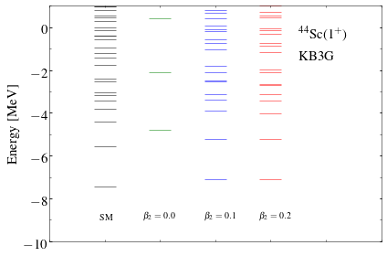

```python
#plt.figure(figsize=(8,6))
plt.scatter(Sc44_SM_J1['iloc'], Sc44_SM_J1['EJ1'],
            c='k',marker='_',s=600,label=r'SM')


plt.scatter(Sc44_BGT_GCM_beta00['iloc'], Sc44_BGT_GCM_beta00['E[MeV]'],
            c='green',marker='_',s=600,label=r'$\beta_2=0.0$')

plt.scatter(Sc44_BGT_GCM_beta01['iloc'], Sc44_BGT_GCM_beta01['E[MeV]'],
            c='blue',marker='_',s=600,label=r'$\beta_2=0.1$')


plt.scatter(Sc44_BGT_GCM_beta02['iloc'], Sc44_BGT_GCM_beta02['E[MeV]'],
            c='red',marker='_',s=600,label=r'$\beta_2=0.2$')



plt.gca().yaxis.set_major_locator(ticker.MultipleLocator(2))
plt.gca().yaxis.set_minor_locator(ticker.MultipleLocator(1))


plt.gca().xaxis.set_major_locator(ticker.MultipleLocator(1))
plt.gca().xaxis.set_minor_locator(ticker.MultipleLocator(1))

plt.xticks([])

plt.ylabel('Energy [MeV]', fontsize=15)
plt.text(2.5,-0.5,r'$^{44}$Sc($1^+$)',fontsize=15)#

plt.text(2.5,-1.5,r'KB3G',fontsize=15)

plt.text(-1.1,-9,'SM')
plt.text(-0.3,-9,r'$\beta_2=0.0$')
plt.text(0.8,-9,r'$\beta_2=0.1$')
plt.text(1.8,-9,r'$\beta_2=0.2$')
#plt.text(2.8,-9,r'GCM$(\beta_2=0.3)$')


plt.xlim(-2,4)
plt.ylim(-10,1)

plt.tight_layout()
plt.savefig('/Users/jmyao/Documents/WorkSpace/Talks/2019/src/GT/Sc44_EJ1.eps');
```

# 48Sc

```python
df4Sc48_SM = read_data('Sc48/energy.dat','Sc48/BGTs.dat')

df4Sc48_SM_400 = read_data('Sc48/energy_400.dat','Sc48/BGTs_400.dat')
```

```python
df4Sc48_SM['BGTs2'] = df4Sc48_SM['BGTs']*3*8
df4Sc48_SM_400['BGTs2'] = df4Sc48_SM_400['BGTs']*3*8

df4Sc48_SM['MGTs2'] = df4Sc48_SM['MGTs']*np.sqrt(3*8)
df4Sc48_SM_400['MGTs2'] = df4Sc48_SM_400['MGTs']*np.sqrt(3*8)
```

```python
df4Sc48_SM_400.head()
```

|  | EJ1 | MGTs | BGTs | BGTs2 | MGTs2 |
| --- | --- | --- | --- | --- | --- |
| 0 | -11.376905 | -0.291479 | 0.084960 | 2.039040 | -1.427950 |
| 1 | -10.928084 | -0.075825 | 0.005749 | 0.137986 | -0.371465 |
| 2 | -10.443736 | -0.101200 | 0.010241 | 0.245795 | -0.495777 |
| 3 | -9.945535 | -0.038871 | 0.001511 | 0.036263 | -0.190428 |
| 4 | -9.444688 | 0.023961 | 0.000574 | 0.013779 | 0.117384 |

```python
-1.427950*-1.427950
```

```
2.0390412025
```

```python
df4Sc48_SM['BGTs2'].sum()
```

```
24.000000771120003
```

```python
df4Sc48_SM_400['BGTs2'].sum()
```

```
24.000004469856002
```

```python
df4Sc48_SM['iloc']=-1
df4Sc48_SM_400['iloc']=-2
```

```python
# Sc48_BGT_GCM_beta02['BGT(0^+->1^+_m)'].sum()
```

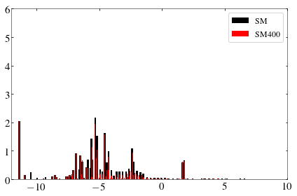

```python
plt.bar(df4Sc48_SM['EJ1'],df4Sc48_SM['BGTs2'],color='k', width=0.15,label='SM')
plt.bar(df4Sc48_SM_400['EJ1'],df4Sc48_SM_400['BGTs2'],color='r', width=0.05,label='SM400')
plt.xlim(-12,10)
plt.ylim(0,6)
plt.legend(fontsize=12)
```

```python
Sc48_BGT_GCM_beta00= pd.read_csv('Sc48/BGT_Ca2Sc_GCM2beta00.dat',delimiter=r'\s+')

Sc48_BGT_GCM_beta00['iloc']=0
```

```python
Sc48_BGT_GCM_beta01= pd.read_csv('Sc48/BGT_Ca2Sc_GCM2beta01.dat',delimiter=r'\s+')

Sc48_BGT_GCM_beta01['iloc']=1
```

```python
Sc48_BGT_GCM_beta02= pd.read_csv('Sc48/BGT_Ca2Sc_GCM2beta02.dat',delimiter=r'\s+')

Sc48_BGT_GCM_beta02['iloc']=2
```

```python
Sc48_BGT_GCM_beta02['BGT(0^+->1^+_m)'].sum()
```

```
23.352488
```

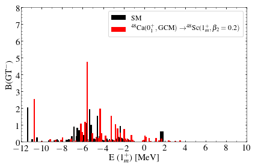

```python
plt.bar(df4Sc48_SM_400['EJ1'],df4Sc48_SM_400['BGTs2'],color='k', width=0.15,label='SM')

plt.bar(Sc48_BGT_GCM_beta02['E[MeV]'],Sc48_BGT_GCM_beta02['BGT(0^+->1^+_m)'],color='red',
        width=0.15,label=r'$^{48}$Ca($0^+_1, {\rm GCM})$ $\to ^{48}$Sc($1^+_m, \beta_2=0.2)$')



plt.xlabel(r'E ($1^+_m$) [MeV]',fontsize=15)
plt.ylabel(r'B(GT$^-$)',fontsize=15)
plt.xlim(-12,10)
plt.ylim(0,8)
plt.legend(fontsize=12)


plt.gca().yaxis.set_major_locator(ticker.MultipleLocator(1))
plt.gca().yaxis.set_minor_locator(ticker.MultipleLocator(0.2))


plt.gca().xaxis.set_major_locator(ticker.MultipleLocator(2))
plt.gca().xaxis.set_minor_locator(ticker.MultipleLocator(1))

plt.tight_layout()
plt.savefig('/Users/jmyao/Documents/WorkSpace/Talks/2019/src/GT/Sc48_BGT_GCM2beta02_revised.eps');
```

```python
Sc48_BGT_GCM_beta02['iloc']=2
Sc48_BGT_GCM_beta02.head()
```

|  | 1^+_m | E[MeV] | M_GT(final) | BGT(0^+->1^+_m) | iloc |
| --- | --- | --- | --- | --- | --- |
| 0 | 1 | -10.71122 | 1.596054 | 2.547390 | 2 |
| 1 | 2 | -10.00010 | 0.188467 | 0.035520 | 2 |
| 2 | 3 | -9.17754 | 0.382797 | 0.146533 | 2 |
| 3 | 4 | -8.62668 | -0.313858 | 0.098507 | 2 |
| 4 | 5 | -8.09980 | 0.361019 | 0.130335 | 2 |

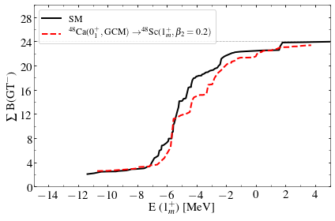

```python
# plt.plot(df4Sc48_SM['EJ1'],np.cumsum(df4Sc48_SM['BGTs']*8),'-',color='k',
#         linewidth=2,label=r'SM')

plt.plot(df4Sc48_SM_400['EJ1'],np.cumsum(df4Sc48_SM_400['BGTs2']),'-',color='k',
        linewidth=2,label=r'SM')



plt.plot(Sc48_BGT_GCM_beta02['E[MeV]'],np.cumsum(Sc48_BGT_GCM_beta02['BGT(0^+->1^+_m)']),'--',color='red',
         linewidth=2,label=r'$^{48}$Ca($0^+_1, {\rm GCM})$ $\to ^{48}$Sc($1^+_m, \beta_2=0.2)$')

plt.xlabel(r'E ($1^+_m$) [MeV]',fontsize=15)
plt.ylabel(r'$\sum$ B(GT$^-$)',fontsize=15)
plt.xlim(-15,5)
plt.ylim(0,30)
plt.legend(loc=2,fontsize=12)

plt.axhline(24,linestyle=':',c='k')

plt.gca().yaxis.set_major_locator(ticker.MultipleLocator(4))
plt.gca().yaxis.set_minor_locator(ticker.MultipleLocator(2))


plt.gca().xaxis.set_major_locator(ticker.MultipleLocator(2))
plt.gca().xaxis.set_minor_locator(ticker.MultipleLocator(1))

plt.tight_layout()
plt.savefig('/Users/jmyao/Documents/WorkSpace/Talks/2019/src/GT/Sc48_BGT_Sum.eps');
```

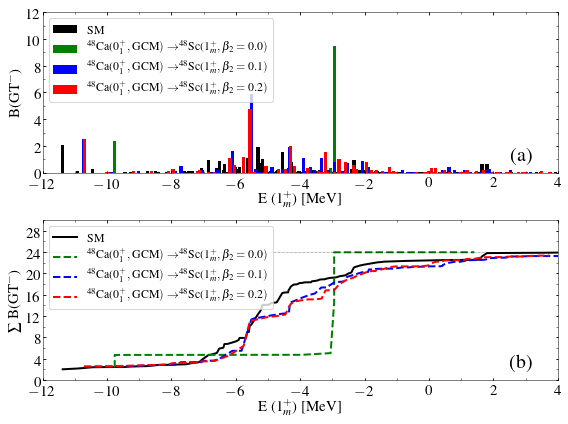

```python
plt.subplots(2, 2, sharex=True, sharey=False, figsize=(8,6))

plt.subplot(2,1,1)

plt.bar(df4Sc48_SM_400['EJ1'],df4Sc48_SM_400['BGTs2'],color='k', width=0.1,label='SM')


plt.bar(Sc48_BGT_GCM_beta00['E[MeV]'],Sc48_BGT_GCM_beta00['BGT(0^+->1^+_m)'],color='green',
        width=0.1,label=r'$^{48}$Ca($0^+_1, {\rm GCM})$ $\to ^{48}$Sc($1^+_m, \beta_2=0.0)$')

plt.bar(Sc48_BGT_GCM_beta01['E[MeV]'],Sc48_BGT_GCM_beta01['BGT(0^+->1^+_m)'],color='blue',
        width=0.1,label=r'$^{48}$Ca($0^+_1, {\rm GCM})$ $\to ^{48}$Sc($1^+_m, \beta_2=0.1)$')

plt.bar(Sc48_BGT_GCM_beta02['E[MeV]'],Sc48_BGT_GCM_beta02['BGT(0^+->1^+_m)'],color='red',
        width=0.1,label=r'$^{48}$Ca($0^+_1, {\rm GCM})$ $\to ^{48}$Sc($1^+_m, \beta_2=0.2)$')


plt.xlabel(r'E ($1^+_m$) [MeV]',fontsize=15)
plt.ylabel(r'B(GT$^-$)',fontsize=15)
plt.xlim(-12,4)
plt.ylim(0,12)
plt.legend(loc=2,fontsize=12)


plt.gca().yaxis.set_major_locator(ticker.MultipleLocator(2))
plt.gca().yaxis.set_minor_locator(ticker.MultipleLocator(1))


plt.gca().xaxis.set_major_locator(ticker.MultipleLocator(2))
plt.gca().xaxis.set_minor_locator(ticker.MultipleLocator(1))


plt.text(0.95,0.05,'(a)',fontsize=20,
         transform=plt.gca().transAxes, ha='right', va='bottom')

plt.subplot(2,1,2)


plt.plot(df4Sc48_SM_400['EJ1'],np.cumsum(df4Sc48_SM_400['BGTs2']),'-',color='k',
        linewidth=2,label=r'SM')





plt.plot(Sc48_BGT_GCM_beta00['E[MeV]'],np.cumsum(Sc48_BGT_GCM_beta00['BGT(0^+->1^+_m)']),'--',color='green',
         linewidth=2,label=r'$^{48}$Ca($0^+_1, {\rm GCM})$ $\to ^{48}$Sc($1^+_m, \beta_2=0.0)$')


plt.plot(Sc48_BGT_GCM_beta01['E[MeV]'],np.cumsum(Sc48_BGT_GCM_beta01['BGT(0^+->1^+_m)']),'--',color='blue',
         linewidth=2,label=r'$^{48}$Ca($0^+_1, {\rm GCM})$ $\to ^{48}$Sc($1^+_m, \beta_2=0.1)$')

plt.plot(Sc48_BGT_GCM_beta02['E[MeV]'],np.cumsum(Sc48_BGT_GCM_beta02['BGT(0^+->1^+_m)']),'--',color='red',
         linewidth=2,label=r'$^{48}$Ca($0^+_1, {\rm GCM})$ $\to ^{48}$Sc($1^+_m, \beta_2=0.2)$')


plt.xlabel(r'E ($1^+_m$) [MeV]',fontsize=15)
plt.ylabel(r'$\sum$ B(GT$^-$)',fontsize=15)
plt.xlim(-12,4)
plt.ylim(0,30)

plt.legend(loc=2,fontsize=12)

plt.axhline(24,linestyle=':',c='k')

plt.gca().yaxis.set_major_locator(ticker.MultipleLocator(4))
plt.gca().yaxis.set_minor_locator(ticker.MultipleLocator(2))


plt.gca().xaxis.set_major_locator(ticker.MultipleLocator(2))
plt.gca().xaxis.set_minor_locator(ticker.MultipleLocator(1))

plt.text(0.95,0.05,'(b)',fontsize=20,
         transform=plt.gca().transAxes, ha='right', va='bottom')

plt.tight_layout()
plt.savefig('/Users/jmyao/Documents/WorkSpace/Talks/2019/src/GT/Sc48_BGT_Sum.eps');
```

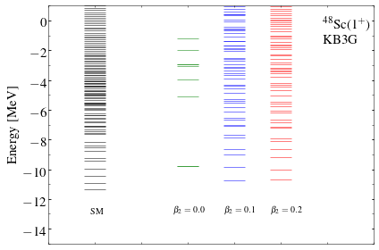

```python
#plt.figure(figsize=(8,6))
plt.scatter(df4Sc48_SM_400['iloc'], df4Sc48_SM_400['EJ1'],
            c='k',marker='_',s=600,label=r'SM')

plt.scatter(Sc48_BGT_GCM_beta00['iloc'], Sc48_BGT_GCM_beta00['E[MeV]'],
            c='g',marker='_',s=600,label=r'$\beta_2=0.2$')


plt.scatter(Sc48_BGT_GCM_beta01['iloc'], Sc48_BGT_GCM_beta01['E[MeV]'],
            c='blue',marker='_',s=600,label=r'$\beta_2=0.1$')

plt.scatter(Sc48_BGT_GCM_beta02['iloc'], Sc48_BGT_GCM_beta02['E[MeV]'],
            c='r',marker='_',s=600,label=r'$\beta_2=0.2$')


plt.gca().yaxis.set_major_locator(ticker.MultipleLocator(2))
plt.gca().yaxis.set_minor_locator(ticker.MultipleLocator(1))


plt.gca().xaxis.set_major_locator(ticker.MultipleLocator(1))
plt.gca().xaxis.set_minor_locator(ticker.MultipleLocator(1))

plt.xticks([])

plt.ylabel('Energy [MeV]', fontsize=15)
plt.text(2.9,-0.5,r'$^{48}$Sc($1^+$)',fontsize=15)#

plt.text(2.9,-1.5,r'KB3G',fontsize=15)

plt.text(-2.1,-13,'SM')
plt.text(-0.3,-13,r'$\beta_2=0.0$')
plt.text(0.8,-13,r'$\beta_2=0.1$')
plt.text(1.8,-13,r'$\beta_2=0.2$')
#plt.text(2.8,-9,r'GCM$(\beta_2=0.3)$')


plt.xlim(-3,4)
plt.ylim(-15,1)

plt.tight_layout()
plt.savefig('/Users/jmyao/Documents/WorkSpace/Talks/2019/src/GT/Sc48_EJ1.eps');
```

```python
Ti48_Sc48_SM=read_data('Sc48/energy2.dat','Sc48/BGTs2.dat')
Ti48_Sc48_SM['iloc']=-1

Ti48_Sc48_SM['BGTs2']=Ti48_Sc48_SM['BGTs']*1.2132925
Ti48_Sc48_SM['MGTs2']=Ti48_Sc48_SM['MGTs']*np.sqrt(1.2132925)
```

```python
Ti48_Sc48_SM.head()
```

|  | EJ1 | MGTs | BGTs | iloc | BGTs2 | MGTs2 |
| --- | --- | --- | --- | --- | --- | --- |
| 0 | -11.376905 | 0.196711 | 0.038695 | -1 | 0.046949 | 0.216676 |
| 1 | -10.928084 | -0.316983 | 0.100478 | -1 | 0.121909 | -0.349155 |
| 2 | -10.443736 | -0.375161 | 0.140746 | -1 | 0.170766 | -0.413238 |
| 3 | -9.945535 | -0.407845 | 0.166338 | -1 | 0.201816 | -0.449239 |
| 4 | -9.444688 | -0.475502 | 0.226102 | -1 | 0.274328 | -0.523763 |

```python
Ti48_Sc48_BGT_GCM_beta01= pd.read_csv('Sc48/BGT_Ti2Sc_GCM2beta01.dat',delimiter=r'\s+')

Ti48_Sc48_BGT_GCM_beta01['iloc']=1

Ti48_Sc48_BGT_GCM_beta02= pd.read_csv('Sc48/BGT_Ti2Sc_GCM2beta02.dat',delimiter=r'\s+')

Ti48_Sc48_BGT_GCM_beta02['iloc']=2
```

```python
Ti48_Sc48_BGT_GCM_beta01['BGT(0^+->1^+_m)'].sum(), Ti48_Sc48_BGT_GCM_beta02['BGT(0^+->1^+_m)'].sum()
```

```
(2.075671, 2.2371899999999996)
```

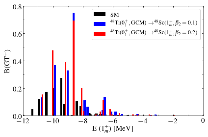

```python
plt.bar(Ti48_Sc48_SM['EJ1'],Ti48_Sc48_SM['BGTs2'],color='k', width=0.15,label='SM')


plt.bar(Ti48_Sc48_BGT_GCM_beta01['E[MeV]'],Ti48_Sc48_BGT_GCM_beta01['BGT(0^+->1^+_m)'],color='blue',
        width=0.15,label=r'$^{48}$Ti($0^+_1, {\rm GCM})$ $\to ^{48}$Sc($1^+_m, \beta_2=0.1)$')

plt.bar(Ti48_Sc48_BGT_GCM_beta02['E[MeV]'],Ti48_Sc48_BGT_GCM_beta02['BGT(0^+->1^+_m)'],color='red',
        width=0.1,label=r'$^{48}$Ti($0^+_1, {\rm GCM})$ $\to ^{48}$Sc($1^+_m, \beta_2=0.2)$')



plt.xlabel(r'E ($1^+_m$) [MeV]',fontsize=15)
plt.ylabel(r'B(GT$^+$)',fontsize=15)
plt.xlim(-12,0)
plt.ylim(0,0.8)
plt.legend(fontsize=12)


plt.gca().yaxis.set_major_locator(ticker.MultipleLocator(0.2))
plt.gca().yaxis.set_minor_locator(ticker.MultipleLocator(0.1))


plt.gca().xaxis.set_major_locator(ticker.MultipleLocator(2))
plt.gca().xaxis.set_minor_locator(ticker.MultipleLocator(1))

plt.tight_layout()
plt.savefig('/Users/jmyao/Documents/WorkSpace/Talks/2019/src/GT/Ti2Sc48_BGT.eps');
```

```python
Ti48_Sc48_BGT_beta03np0_beta02= pd.read_csv('Sc48/BGT_Ti2Sc_beta03np0_beta02.dat',delimiter=r'\s+')
Ti48_Sc48_BGT_beta03np2_beta02= pd.read_csv('Sc48/BGT_Ti2Sc_beta03np2_beta02.dat',delimiter=r'\s+')
Ti48_Sc48_BGT_beta03np4_beta02= pd.read_csv('Sc48/BGT_Ti2Sc_beta03np4_beta02.dat',delimiter=r'\s+')



Ti48_Sc48_BGT_beta03npm_beta02= pd.read_csv('Sc48/BGT_Ti2Sc_beta03npm_beta02.dat',delimiter=r'\s+')
```

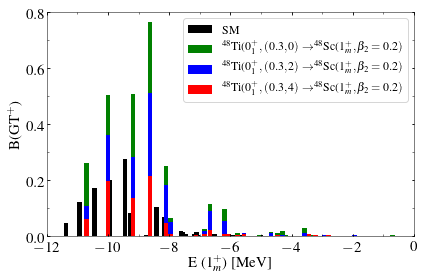

```python
plt.bar(Ti48_Sc48_SM['EJ1'],Ti48_Sc48_SM['BGTs2'],color='k', width=0.15,label='SM') # a factor 3 is multiplied while taking the data




plt.bar(Ti48_Sc48_BGT_beta03np0_beta02['E[MeV]'],Ti48_Sc48_BGT_beta03np0_beta02['BGT(0^+->1^+_m)'],color='green',
        width=0.15,label=r'$^{48}$Ti($0^+_1,(0.3,0) $ $\to ^{48}$Sc($1^+_m, \beta_2=0.2)$')



plt.bar(Ti48_Sc48_BGT_beta03np2_beta02['E[MeV]'],Ti48_Sc48_BGT_beta03np2_beta02['BGT(0^+->1^+_m)'],color='blue',
         width=0.15,label=r'$^{48}$Ti($0^+_1,(0.3,2) $ $\to ^{48}$Sc($1^+_m, \beta_2=0.2)$')

plt.bar(Ti48_Sc48_BGT_beta03np4_beta02['E[MeV]'],Ti48_Sc48_BGT_beta03np4_beta02['BGT(0^+->1^+_m)'],color='red',
         width=0.15,label=r'$^{48}$Ti($0^+_1,(0.3,4) $ $\to ^{48}$Sc($1^+_m, \beta_2=0.2)$')



plt.xlabel(r'E ($1^+_m$) [MeV]',fontsize=15)
plt.ylabel(r'B(GT$^+$)',fontsize=15)
plt.xlim(-12,0)
plt.ylim(0,0.8)
plt.legend(fontsize=12)


plt.gca().yaxis.set_major_locator(ticker.MultipleLocator(0.2))
plt.gca().yaxis.set_minor_locator(ticker.MultipleLocator(0.1))


plt.gca().xaxis.set_major_locator(ticker.MultipleLocator(2))
plt.gca().xaxis.set_minor_locator(ticker.MultipleLocator(1))

plt.tight_layout()
plt.savefig('/Users/jmyao/Documents/WorkSpace/Talks/2019/src/GT/Ti2Sc48_BGT.eps');
```

```python
Ti48_Sc48_BGT_beta03npm_beta02['BGT(0^+->1^+_m)'].sum()
```

```
1.751755
```

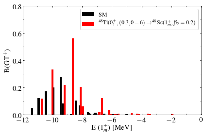

```python
plt.bar(Ti48_Sc48_SM['EJ1'],Ti48_Sc48_SM['BGTs2'],color='k', width=0.15,label='SM')


plt.bar(Ti48_Sc48_BGT_beta03npm_beta02['E[MeV]'],Ti48_Sc48_BGT_beta03npm_beta02['BGT(0^+->1^+_m)'],color='r',
        width=0.15,label=r'$^{48}$Ti($0^+_1,(0.3,0-6) $ $\to ^{48}$Sc($1^+_m, \beta_2=0.2)$')







plt.xlabel(r'E ($1^+_m$) [MeV]',fontsize=15)
plt.ylabel(r'B(GT$^+$)',fontsize=15)
plt.xlim(-12,0)
plt.ylim(0,0.8)
plt.legend(fontsize=12)


plt.gca().yaxis.set_major_locator(ticker.MultipleLocator(0.2))
plt.gca().yaxis.set_minor_locator(ticker.MultipleLocator(0.1))


plt.gca().xaxis.set_major_locator(ticker.MultipleLocator(2))
plt.gca().xaxis.set_minor_locator(ticker.MultipleLocator(1))

plt.tight_layout()
plt.savefig('/Users/jmyao/Documents/WorkSpace/Talks/2019/src/GT/Ti2Sc48_BGT_mixing_np.eps');
```

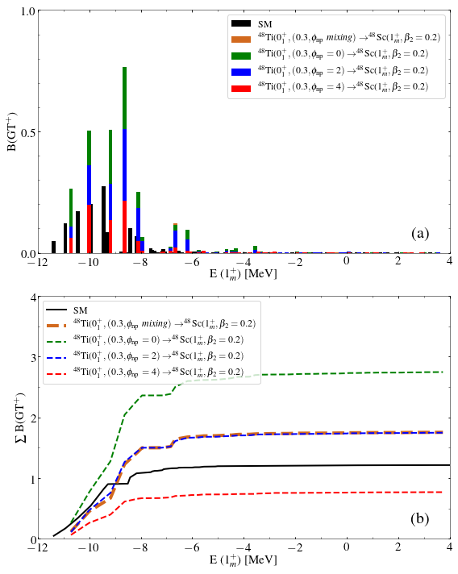

```python
plt.subplots(2, 2, sharex=True, sharey=False, figsize=(8,10))

plt.subplot(2,1,1)


plt.bar(Ti48_Sc48_SM['EJ1'],Ti48_Sc48_SM['BGTs2'],color='k', width=0.15,label='SM')


plt.bar(Ti48_Sc48_BGT_beta03npm_beta02['E[MeV]'],Ti48_Sc48_BGT_beta03npm_beta02['BGT(0^+->1^+_m)'],color='chocolate',
        width=0.15,label=r'$^{48}$Ti($0^+_1,(0.3, \phi_{\rm np}~mixing) $ $\to ^{48}$Sc($1^+_m, \beta_2=0.2)$')


plt.bar(Ti48_Sc48_BGT_beta03np0_beta02['E[MeV]'],Ti48_Sc48_BGT_beta03np0_beta02['BGT(0^+->1^+_m)'],color='green',
        width=0.15,label=r'$^{48}$Ti($0^+_1,(0.3,\phi_{\rm np}=0) $ $\to ^{48}$Sc($1^+_m, \beta_2=0.2)$')



plt.bar(Ti48_Sc48_BGT_beta03np2_beta02['E[MeV]'],Ti48_Sc48_BGT_beta03np2_beta02['BGT(0^+->1^+_m)'],color='blue',
         width=0.15,label=r'$^{48}$Ti($0^+_1,(0.3,\phi_{\rm np}=2) $ $\to ^{48}$Sc($1^+_m, \beta_2=0.2)$')

plt.bar(Ti48_Sc48_BGT_beta03np4_beta02['E[MeV]'],Ti48_Sc48_BGT_beta03np4_beta02['BGT(0^+->1^+_m)'],color='red',
         width=0.15,label=r'$^{48}$Ti($0^+_1,(0.3,\phi_{\rm np}=4) $ $\to ^{48}$Sc($1^+_m, \beta_2=0.2)$')




plt.xlabel(r'E ($1^+_m$) [MeV]',fontsize=15)
plt.ylabel(r'B(GT$^+$)',fontsize=15)
plt.xlim(-12,4)
plt.ylim(0,1)
plt.legend(fontsize=12)


plt.gca().yaxis.set_major_locator(ticker.MultipleLocator(0.5))
plt.gca().yaxis.set_minor_locator(ticker.MultipleLocator(0.1))


plt.gca().xaxis.set_major_locator(ticker.MultipleLocator(2))
plt.gca().xaxis.set_minor_locator(ticker.MultipleLocator(1))


plt.text(0.95,0.05,'(a)',fontsize=20,
         transform=plt.gca().transAxes, ha='right', va='bottom')

plt.subplot(2,1,2)


plt.plot(Ti48_Sc48_SM['EJ1'],np.cumsum(Ti48_Sc48_SM['BGTs2']),'-',color='k',
        linewidth=2,label=r'SM')


plt.plot(Ti48_Sc48_BGT_beta03npm_beta02['E[MeV]'],np.cumsum(Ti48_Sc48_BGT_beta03npm_beta02['BGT(0^+->1^+_m)']),
         '--',color='chocolate',
         linewidth=4,label=r'$^{48}$Ti($0^+_1,(0.3, \phi_{\rm np}~mixing) $ $\to ^{48}$Sc($1^+_m, \beta_2=0.2)$')


plt.plot(Ti48_Sc48_BGT_beta03np0_beta02['E[MeV]'],np.cumsum(Ti48_Sc48_BGT_beta03np0_beta02['BGT(0^+->1^+_m)']),'--',color='green',
         linewidth=2,label=r'$^{48}$Ti($0^+_1,(0.3,\phi_{\rm np}=0) $ $\to ^{48}$Sc($1^+_m, \beta_2=0.2)$')


plt.plot(Ti48_Sc48_BGT_beta03np2_beta02['E[MeV]'],np.cumsum(Ti48_Sc48_BGT_beta03np2_beta02['BGT(0^+->1^+_m)']),'--',color='blue',
       linewidth=2,label=r'$^{48}$Ti($0^+_1,(0.3,\phi_{\rm np}=2) $ $\to ^{48}$Sc($1^+_m, \beta_2=0.2)$')

plt.plot(Ti48_Sc48_BGT_beta03np4_beta02['E[MeV]'],np.cumsum(Ti48_Sc48_BGT_beta03np4_beta02['BGT(0^+->1^+_m)']),'--',color='red',
       linewidth=2,label=r'$^{48}$Ti($0^+_1,(0.3,\phi_{\rm np}=4) $ $\to ^{48}$Sc($1^+_m, \beta_2=0.2)$')


plt.xlabel(r'E ($1^+_m$) [MeV]',fontsize=15)
plt.ylabel(r'$\sum$ B(GT$^+$)',fontsize=15)
plt.xlim(-12,4)
plt.ylim(0,4)

plt.legend(loc=2,fontsize=12)

plt.axhline(24,linestyle=':',c='k')

plt.gca().yaxis.set_major_locator(ticker.MultipleLocator(1))
plt.gca().yaxis.set_minor_locator(ticker.MultipleLocator(0.5))


plt.gca().xaxis.set_major_locator(ticker.MultipleLocator(2))
plt.gca().xaxis.set_minor_locator(ticker.MultipleLocator(1))

plt.text(0.95,0.05,'(b)',fontsize=20,
         transform=plt.gca().transAxes, ha='right', va='bottom')

plt.tight_layout()
plt.savefig('/Users/jmyao/Documents/WorkSpace/Talks/2019/src/GT/Ti2Sc48_BGT_Sum_np.eps');
```

```python
Ti48_Sc48_BGT_GCM56_beta02= pd.read_csv('Sc48/BGT_Ti2Sc_GCM56_beta02.dat',delimiter=r'\s+')
```

[output not shown]

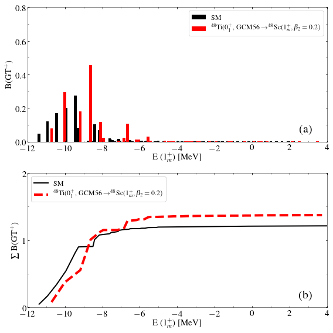

```python
plt.subplots(2, 2, sharex=True, sharey=False, figsize=(8,8))

plt.subplot(2,1,1)


plt.bar(Ti48_Sc48_SM['EJ1'],Ti48_Sc48_SM['BGTs2'],color='k', width=0.15,label='SM')


plt.bar(Ti48_Sc48_BGT_GCM56_beta02['E[MeV]'],Ti48_Sc48_BGT_GCM56_beta02['BGT(0^+->1^+_m)'],
        color='red',
        width=0.15,label=r'$^{48}$Ti($0^+_1$, GCM56  $\to ^{48}$Sc($1^+_m, \beta_2=0.2)$')




plt.xlabel(r'E ($1^+_m$) [MeV]',fontsize=15)
plt.ylabel(r'B(GT$^+$)',fontsize=15)
plt.xlim(-12,4)
plt.ylim(0,0.8)
plt.legend(fontsize=12)


plt.gca().yaxis.set_major_locator(ticker.MultipleLocator(0.2))
plt.gca().yaxis.set_minor_locator(ticker.MultipleLocator(0.1))


plt.gca().xaxis.set_major_locator(ticker.MultipleLocator(2))
plt.gca().xaxis.set_minor_locator(ticker.MultipleLocator(1))


plt.text(0.95,0.05,'(a)',fontsize=20,
         transform=plt.gca().transAxes, ha='right', va='bottom')

plt.subplot(2,1,2)


plt.plot(Ti48_Sc48_SM['EJ1'],np.cumsum(Ti48_Sc48_SM['BGTs2']),'-',color='k',
        linewidth=2,label=r'SM')


plt.plot(Ti48_Sc48_BGT_GCM56_beta02['E[MeV]'],np.cumsum(Ti48_Sc48_BGT_GCM56_beta02['BGT(0^+->1^+_m)']),
         '--',color='red',
         linewidth=4,label=r'$^{48}$Ti($0^+_1$, GCM56  $\to ^{48}$Sc($1^+_m, \beta_2=0.2)$')




plt.xlabel(r'E ($1^+_m$) [MeV]',fontsize=15)
plt.ylabel(r'$\sum$ B(GT$^+$)',fontsize=15)
plt.xlim(-12,4)
plt.ylim(0,2)

plt.legend(loc=2,fontsize=12)

plt.axhline(24,linestyle=':',c='k')

plt.gca().yaxis.set_major_locator(ticker.MultipleLocator(1))
plt.gca().yaxis.set_minor_locator(ticker.MultipleLocator(0.5))


plt.gca().xaxis.set_major_locator(ticker.MultipleLocator(2))
plt.gca().xaxis.set_minor_locator(ticker.MultipleLocator(1))

plt.text(0.95,0.05,'(b)',fontsize=20,
         transform=plt.gca().transAxes, ha='right', va='bottom')

plt.tight_layout()
plt.savefig('/Users/jmyao/Documents/WorkSpace/Talks/2019/src/GT/Ti2Sc48_BGT_GCM56_beta02.eps');
```

```python
Ti48_Sc48_SM.head(10)
```

|  | EJ1 | MGTs | BGTs | iloc | BGTs2 | MGTs2 |
| --- | --- | --- | --- | --- | --- | --- |
| 0 | -11.376905 | 0.196711 | 0.038695 | -1 | 0.046949 | 0.216676 |
| 1 | -10.928084 | -0.316983 | 0.100478 | -1 | 0.121909 | -0.349155 |
| 2 | -10.443736 | -0.375161 | 0.140746 | -1 | 0.170766 | -0.413238 |
| 3 | -9.945535 | -0.407845 | 0.166338 | -1 | 0.201816 | -0.449239 |
| 4 | -9.444688 | -0.475502 | 0.226102 | -1 | 0.274328 | -0.523763 |
| 5 | -9.273608 | 0.262072 | 0.068682 | -1 | 0.083331 | 0.288671 |
| 6 | -8.743181 | 0.066137 | 0.004374 | -1 | 0.005307 | 0.072850 |
| 7 | -8.500888 | -0.037222 | 0.001385 | -1 | 0.001681 | -0.041000 |
| 8 | -8.413491 | 0.291177 | 0.084784 | -1 | 0.102868 | 0.320730 |
| 9 | -8.160779 | 0.236244 | 0.055811 | -1 | 0.067715 | 0.260222 |

```python
Ti48_Sc48_SM['BGTs'].sum()
```

```
1.000000003649
```

```python
Ti48_Sc48_SM['BGTs2'].sum()
```

```
1.2132925044273044
```

```python
df4Sc48_SM.head(10)
```

|  | EJ1 | MGTs | BGTs | BGTs2 | MGTs2 |
| --- | --- | --- | --- | --- | --- |
| 0 | -11.376905 | -0.291479 | 0.084960 | 2.039040 | -1.427950 |
| 1 | -10.928084 | 0.075825 | 0.005749 | 0.137986 | 0.371465 |
| 2 | -10.443736 | 0.101200 | 0.010241 | 0.245795 | 0.495777 |
| 3 | -9.945535 | 0.038871 | 0.001511 | 0.036263 | 0.190428 |
| 4 | -9.444688 | -0.023961 | 0.000574 | 0.013779 | -0.117384 |
| 5 | -9.273608 | 0.056183 | 0.003157 | 0.075757 | 0.275239 |
| 6 | -8.743153 | -0.060790 | 0.003695 | 0.088690 | -0.297809 |
| 7 | -8.500835 | 0.075894 | 0.005760 | 0.138238 | 0.371803 |
| 8 | -8.413487 | -0.054257 | 0.002944 | 0.070652 | -0.265804 |
| 9 | -8.160775 | 0.027434 | 0.000753 | 0.018063 | 0.134399 |

```python
M2nu,M2nu_cum=NME_2nuDBD(Ti48_Sc48_SM,df4Sc48_SM,'MGTs2',-13.58392)
print('M_2nu={}'.format(M2nu*(0.77**2)))
```

```
Q-value:4.268219200000245, E0=1.857
M_2nu=-0.08154617818054355
```

```python
M2nu_cum_df= pd.DataFrame(M2nu_cum,columns=['Ex','M2nu'])
```

```python
GCM_M2nu,GCM_M2nu_cum=NME_2nuDBD(Ti48_Sc48_BGT_GCM56_beta02,Sc48_BGT_GCM_beta02,'M_GT(final)',-12.2848)
print('M_2nu={}'.format(GCM_M2nu*(0.77**2)))
```

```
Q-value:4.268219200000245, E0=1.857
M_2nu=0.11501879629216898
```

```python
GCM_M2nu_cum_df= pd.DataFrame(GCM_M2nu_cum,columns=['Ex','M2nu'])
```

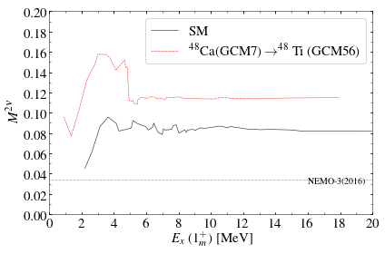

```python
factor = 0.77**2




plt.plot(M2nu_cum_df['Ex'],abs(M2nu_cum_df['M2nu'])*factor,'-',color='k',label='SM')

plt.plot(GCM_M2nu_cum_df['Ex'],abs(GCM_M2nu_cum_df['M2nu'])*factor,'--',color='r',label=r'$^{48}$Ca(GCM7) $\to ^{48}$ Ti (GCM56)')


#plt.plot(GCM_M2nu_cum_df['Ex'],abs(GCM_M2nu_cum_df['M2nu'])*factor/1.4,'--',color='g',label=r'$^{48}$Ca(GCM7) $\to ^{48}$ Ti (GCM56)')


plt.legend(fontsize=15)

plt.xlabel(r'$E_x$ ($1^+_m$) [MeV]',fontsize=15)
plt.ylabel(r'$M^{2\nu}$',fontsize=15)
plt.xlim(0,20)
plt.ylim(0,0.2)

# plt.legend(loc=2,fontsize=12)

# plt.axhline(24,linestyle=':',c='k')

plt.gca().yaxis.set_major_locator(ticker.MultipleLocator(0.02))
plt.gca().yaxis.set_minor_locator(ticker.MultipleLocator(0.01))


plt.gca().xaxis.set_major_locator(ticker.MultipleLocator(2))
plt.gca().xaxis.set_minor_locator(ticker.MultipleLocator(1))

plt.axhline(0.0342,linestyle=':',color='black')
plt.text(16,0.03,'NEMO-3(2016)')

plt.tight_layout()
plt.savefig('/Users/jmyao/Documents/WorkSpace/Talks/2019/src/GT/Ca2Ti_2nuDBD.eps');
```

# 46Sc

```python
df4Sc46_SM = read_data('Sc46/energy.dat','Sc46/BGTs.dat')
```

```python
df4Sc46_SM['BGTs'].sum()
```

```
3.000002051124
```

```python
df4Sc46_SM['iloc']=-1
```

```python
Sc46_BGT_GCM_beta02= pd.read_csv('Sc46/BGT_Sc2Ca_GCM2beta02.dat',delimiter=r'\s+')

Sc46_BGT_GCM_beta02['iloc']=2
```

```python
Sc46_BGT_GCM_beta02.head()
```

|  | 1^+_m | E[MeV] | M_GT(final) | BGT(0^+->1^+_m) | iloc |
| --- | --- | --- | --- | --- | --- |
| 0 | 1 | -9.15475 | -1.532705 | 2.349186 | 2 |
| 1 | 2 | -7.75929 | 0.507231 | 0.257283 | 2 |
| 2 | 3 | -7.62574 | -0.274662 | 0.075439 | 2 |
| 3 | 4 | -7.09501 | -0.735097 | 0.540367 | 2 |
| 4 | 5 | -6.82846 | 0.212699 | 0.045241 | 2 |

```python
Sc46_BGT_GCM_beta02['BGT(0^+->1^+_m)'].sum()
```

```
17.594836
```

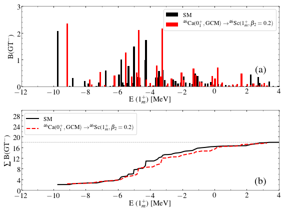

```python
plt.subplots(2, 2, sharex=True, sharey=False, figsize=(8,6))

plt.subplot(2,1,1)

plt.bar(df4Sc46_SM['EJ1'],df4Sc46_SM['BGTs']*6,color='k', width=0.1,label='SM')
plt.bar(Sc46_BGT_GCM_beta02['E[MeV]'],Sc46_BGT_GCM_beta02['BGT(0^+->1^+_m)'],color='red',fill=bool,
        width=0.1,label=r'$^{46}$Ca($0^+_1, {\rm GCM})$ $\to ^{46}$Sc($1^+_m, \beta_2=0.2)$')


plt.xlabel(r'E ($1^+_m$) [MeV]',fontsize=15)
plt.ylabel(r'B(GT$^-$)',fontsize=15)
plt.xlim(-12,4)
plt.ylim(0,3)
plt.legend(fontsize=12)


plt.gca().yaxis.set_major_locator(ticker.MultipleLocator(1))
plt.gca().yaxis.set_minor_locator(ticker.MultipleLocator(0.2))


plt.gca().xaxis.set_major_locator(ticker.MultipleLocator(2))
plt.gca().xaxis.set_minor_locator(ticker.MultipleLocator(1))


plt.text(0.95,0.15,'(a)',fontsize=20,
         transform=plt.gca().transAxes, ha='right', va='bottom')

plt.subplot(2,1,2)

plt.plot(df4Sc46_SM['EJ1'],np.cumsum(df4Sc46_SM['BGTs']*6),'-',color='k',
        linewidth=2,label=r'SM')



plt.plot(Sc46_BGT_GCM_beta02['E[MeV]'],np.cumsum(Sc46_BGT_GCM_beta02['BGT(0^+->1^+_m)']),'--',color='red',
         linewidth=2,label=r'$^{46}$Ca($0^+_1, {\rm GCM})$ $\to ^{46}$Sc($1^+_m, \beta_2=0.2)$')

plt.xlabel(r'E ($1^+_m$) [MeV]',fontsize=15)
plt.ylabel(r'$\sum$ B(GT$^-$)',fontsize=15)
plt.xlim(-12,4)
plt.ylim(0,30)

plt.legend(loc=2,fontsize=12)

plt.axhline(18,linestyle=':',c='k')

plt.gca().yaxis.set_major_locator(ticker.MultipleLocator(4))
plt.gca().yaxis.set_minor_locator(ticker.MultipleLocator(2))


plt.gca().xaxis.set_major_locator(ticker.MultipleLocator(2))
plt.gca().xaxis.set_minor_locator(ticker.MultipleLocator(1))

plt.text(0.95,0.05,'(b)',fontsize=20,
         transform=plt.gca().transAxes, ha='right', va='bottom')

plt.tight_layout()
plt.savefig('/Users/jmyao/Documents/WorkSpace/Talks/2019/src/GT/Sc46_BGT_Sum.eps');
```

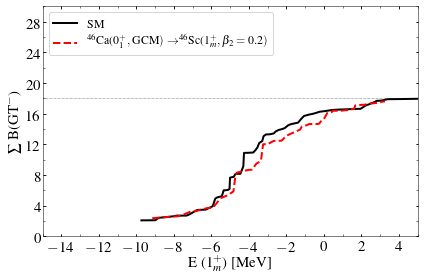

```python
# plt.plot(df4Sc48_SM['EJ1'],np.cumsum(df4Sc48_SM['BGTs']*8),'-',color='k',
#         linewidth=2,label=r'SM')

plt.plot(df4Sc46_SM['EJ1'],np.cumsum(df4Sc46_SM['BGTs']*6),'-',color='k',
        linewidth=2,label=r'SM')



plt.plot(Sc46_BGT_GCM_beta02['E[MeV]'],np.cumsum(Sc46_BGT_GCM_beta02['BGT(0^+->1^+_m)']),'--',color='red',
         linewidth=2,label=r'$^{46}$Ca($0^+_1, {\rm GCM})$ $\to ^{46}$Sc($1^+_m, \beta_2=0.2)$')

plt.xlabel(r'E ($1^+_m$) [MeV]',fontsize=15)
plt.ylabel(r'$\sum$ B(GT$^-$)',fontsize=15)
plt.xlim(-15,5)
plt.ylim(0,30)
plt.legend(loc=2,fontsize=12)

plt.axhline(18,linestyle=':',c='k')

plt.gca().yaxis.set_major_locator(ticker.MultipleLocator(4))
plt.gca().yaxis.set_minor_locator(ticker.MultipleLocator(2))


plt.gca().xaxis.set_major_locator(ticker.MultipleLocator(2))
plt.gca().xaxis.set_minor_locator(ticker.MultipleLocator(1))

plt.tight_layout()
plt.savefig('/Users/jmyao/Documents/WorkSpace/Talks/2019/src/GT/Sc46_BGT_Sum.eps');
```

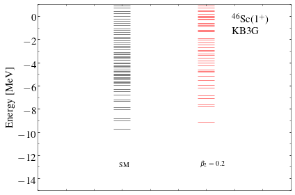

```python
#plt.figure(figsize=(8,6))
plt.scatter(df4Sc46_SM['iloc'], df4Sc46_SM['EJ1'],
            c='k',marker='_',s=600,label=r'SM')

plt.scatter(Sc46_BGT_GCM_beta02['iloc'], Sc46_BGT_GCM_beta02['E[MeV]'],
            c='r',marker='_',s=600,label=r'$\beta_2=0.2$')


plt.gca().yaxis.set_major_locator(ticker.MultipleLocator(2))
plt.gca().yaxis.set_minor_locator(ticker.MultipleLocator(1))


plt.gca().xaxis.set_major_locator(ticker.MultipleLocator(1))
plt.gca().xaxis.set_minor_locator(ticker.MultipleLocator(1))

plt.xticks([])

plt.ylabel('Energy [MeV]', fontsize=15)
plt.text(2.9,-0.5,r'$^{46}$Sc($1^+$)',fontsize=15)#

plt.text(2.9,-1.5,r'KB3G',fontsize=15)

plt.text(-1.1,-13,'SM')
# plt.text(-0.3,-13,r'$\beta_2=0.0$')
# plt.text(0.8,-13,r'$\beta_2=0.1$')
plt.text(1.8,-13,r'$\beta_2=0.2$')
#plt.text(2.8,-9,r'GCM$(\beta_2=0.3)$')


plt.xlim(-4,5)
plt.ylim(-15,1)

plt.tight_layout()
plt.savefig('/Users/jmyao/Documents/WorkSpace/Talks/2019/src/GT/Sc46_EJ1.eps');
```